# R Notebook

Welcome to the file where we finally start doing some modeling. Lets start by grabbing our good old analytics store.

The first step here is to import out most important libraries:

```r
library(DBI)
library(RSQLite)
library(caret)
library(factoextra)
library(ROCR)
library(class)
```

Then, for simplicity and ease of access, we will set our working directory to the folder in which we are working. If you are actually running this notebook instead of just looking at it, remember to change the name of the location to the one of your choosing.

```r
currentwd <- getwd() #so that I can re set my working directory after I'm done
setwd("C:/Users/avg38/Documents/cornell/spring 2018/ds 4100/OscarPredictor")
```

Now that all the setup is done, lets connect to our database.

```r
con <- dbConnect(drv=RSQLite::SQLite(), dbname="moviedata.db")
dbListTables(con) #sanity check - should show 7 names
```

```
[1] "actoroscars"    "actors"         "directoroscars" "directors"      "movieoscars"    "movies"         "moviesfinal"
```

Lets kick this off now and grab our table:

```r
movies <- dbGetQuery(con, "select * from moviesfinal")
movies
```

| mid | title | budget | action | adventure | animation | comedy | crime | documentary | drama | family | fantasy | history | horror | music | mystery | romance | scifi | thriller | war | western | original_language | production_companies | release_date | revenue | runtime | popularity | average_rating | num_votes | actor_1 | … |
| --- | --- | --- | --- | --- | --- | --- | --- | --- | --- | --- | --- | --- | --- | --- | --- | --- | --- | --- | --- | --- | --- | --- | --- | --- | --- | --- | --- | --- | --- | --- |
| 12 | Finding Nemo | 94000000 | 0 | 0 | 1 | 0 | 0 | 0 | 0 | 1 | 0 | 0 | 0 | 0 | 0 | 0 | 0 | 0 | 0 | 0 | en | Pixar and | 2003-05-30 | 940335536 | 100 | 45.421204 | 7.7 | 8083 | 13 | … |
| 22 | Pirates of the Caribbean: The Curse of the Black Pearl | 140000000 | 1 | 1 | 0 | 0 | 0 | 0 | 0 | 0 | 1 | 0 | 0 | 0 | 0 | 0 | 0 | 0 | 0 | 0 | en | Jerry Bruckheimer Films and Walt Disney Pictures and | 2003-07-09 | 655011224 | 143 | 55.482539 | 7.6 | 8950 | 85 | … |
| 24 | Kill Bill: Vol. 1 | 30000000 | 1 | 0 | 0 | 0 | 1 | 0 | 0 | 0 | 0 | 0 | 0 | 0 | 0 | 0 | 0 | 0 | 0 | 0 | en | Miramax Films and A Band Apart and Super Cool ManChu and | 2003-10-10 | 180949045 | 111 | 32.084682 | 7.8 | 6535 | 139 | … |
| 25 | Jarhead | 72000000 | 0 | 0 | 0 | 0 | 0 | 0 | 1 | 0 | 0 | 0 | 0 | 0 | 0 | 0 | 0 | 0 | 1 | 0 | en | Universal Pictures and Red Wagon Entertainment and Neal Street Productions and Motion Picture KAPPA Produktionsgesellschaft and | 2005-11-04 | 96889998 | 123 | 19.980013 | 6.6 | 953 | 134 | … |
| 27 | 9 Songs | 1000000 | 0 | 0 | 0 | 0 | 0 | 0 | 1 | 0 | 0 | 0 | 0 | 1 | 0 | 1 | 0 | 0 | 0 | 0 | en | Revolution Films and | 2004-07-16 | 1574623 | 66 | 14.750917 | 5.0 | 134 | 176 | … |
| 35 | The Simpsons Movie | 75000000 | 0 | 0 | 1 | 1 | 0 | 0 | 0 | 1 | 0 | 0 | 0 | 0 | 0 | 0 | 0 | 0 | 0 | 0 | en | AKOM Production Company and Gracie Films and Rough Draft Feature Animation and Film Roman and 20th Century Fox and | 2007-07-25 | 527068851 | 87 | 24.076227 | 6.9 | 3171 | 198 | … |
| 38 | Eternal Sunshine of the Spotless Mind | 20000000 | 0 | 0 | 0 | 0 | 0 | 0 | 1 | 0 | 0 | 0 | 0 | 0 | 0 | 1 | 1 | 0 | 0 | 0 | en | Focus Features and Anonymous Content and This Is That Productions and | 2004-03-19 | 72258126 | 108 | 29.537841 | 8.0 | 4915 | 206 | … |
| 58 | Pirates of the Caribbean: Dead Man's Chest | 200000000 | 1 | 1 | 0 | 0 | 0 | 0 | 0 | 0 | 1 | 0 | 0 | 0 | 0 | 0 | 0 | 0 | 0 | 0 | en | Walt Disney Pictures and Jerry Bruckheimer Films and Second Mate Productions and | 2006-06-20 | 1065659812 | 151 | 44.266860 | 7.1 | 6747 | 85 | … |
| 59 | A History of Violence | 32000000 | 0 | 0 | 0 | 0 | 1 | 0 | 1 | 0 | 0 | 0 | 0 | 0 | 0 | 0 | 0 | 1 | 0 | 0 | en | New Line Cinema and DC Comics and BenderSpink and | 2005-09-23 | 60740827 | 96 | 19.155996 | 7.0 | 1066 | 110 | … |
| 65 | 8 Mile | 41000000 | 0 | 0 | 0 | 0 | 0 | 0 | 1 | 0 | 0 | 0 | 0 | 0 | 0 | 0 | 0 | 0 | 0 | 0 | en | Mikona Productions GmbH & Co. KG and Imagine Entertainment and | 2002-11-08 | 242875078 | 110 | 10.179921 | 6.8 | 2218 | 325 | … |

[output cut: 990 more lines]

Now we can close our connection. And just in case, make a copy of our dataset for manipulation purposes.

```r
dbDisconnect(con)
```

```
[1] TRUE
```

```r
setwd(currentwd)
stmovies <- movies
```

Now the first thing we have to do is standardize our numerical features - all of them are on vastly different scales. We’ll use a zscore standardization to do this.

```r
stmovies$budget <- (stmovies$budget - mean(stmovies$budget))/sd(stmovies$budget)
stmovies$revenue <- (stmovies$revenue - mean(stmovies$revenue))/sd(stmovies$revenue)
stmovies$runtime <- (stmovies$runtime - mean(stmovies$runtime))/sd(stmovies$runtime)
stmovies$popularity <- (stmovies$popularity - mean(stmovies$popularity))/sd(stmovies$popularity)
stmovies$budget <- (stmovies$budget - mean(stmovies$budget))/sd(stmovies$budget)
stmovies$average_rating <- (stmovies$average_rating - mean(stmovies$average_rating))/sd(stmovies$average_rating)
stmovies$num_votes <- (stmovies$num_votes - mean(stmovies$num_votes))/sd(stmovies$num_votes)
stmovies$total_actor_credits <- (stmovies$total_actor_credits - mean(stmovies$total_actor_credits))/sd(stmovies$total_actor_credits)
stmovies$average_actor_popularity <- (stmovies$average_actor_popularity-mean(stmovies$average_actor_popularity))/sd(stmovies$average_actor_popularity)
stmovies$actor_oscar_nominations <- (stmovies$actor_oscar_nominations - mean(stmovies$actor_oscar_nominations))/sd(stmovies$actor_oscar_nominations)
stmovies$actor_oscar_wins <- (stmovies$actor_oscar_wins - mean(stmovies$actor_oscar_wins))/sd(stmovies$actor_oscar_wins)
stmovies$total_director_credits <- (stmovies$total_director_credits - mean(stmovies$total_director_credits))/sd(stmovies$total_director_credits)
stmovies$average_director_popularity <- (stmovies$average_director_popularity - mean(stmovies$average_director_popularity))/sd(stmovies$average_director_popularity)
stmovies$director_oscar_nominations <- (stmovies$director_oscar_nominations - mean(stmovies$director_oscar_nominations))/sd(stmovies$director_oscar_nominations)
stmovies$director_oscar_wins <- (stmovies$director_oscar_wins - mean(stmovies$director_oscar_wins))/sd(stmovies$director_oscar_wins)
```

First things first, lets split our dataset based on the categories:

```r
bestpicture <- stmovies[stmovies$category == "BEST PICTURE",]
bestanim <- stmovies[stmovies$category == "ANIMATED FEATURE FILM",]
```

This is because the two categories are pretty strictly distinct - movies like *Toy Story 3* and *Up* that got nominated for both are rare - in fact, those are the only two such movies in this dataset. So, generally, a nominee for Animated Feature won’t end up getting a nomination for Best Picture.

Now lets make strictly numerical versions of each one.

```r
bpnumeric <- bestpicture[,c("budget", "revenue", "runtime", "popularity", "average_rating",
            "num_votes", "total_actor_credits", "average_actor_popularity",
            "actor_oscar_nominations", "actor_oscar_wins", "total_director_credits",
            "average_director_popularity", "director_oscar_nominations", "director_oscar_wins", "nominee", "winner")]
banumeric <- bestanim[,c("budget", "revenue", "runtime", "popularity", "average_rating",
            "num_votes", "total_actor_credits", "average_actor_popularity",
            "actor_oscar_nominations", "actor_oscar_wins", "total_director_credits",
            "average_director_popularity", "director_oscar_nominations", "director_oscar_wins", "nominee", "winner")]
```

We also left the classification variables in, just in case. Next, lets set up the training and testing set. We’ll reserve 20% of the data for testing - thats about 500 test cases for the best picture. There are only 200 rows in the best animated feature dataset, but an 80-20 split should still work, if not optimally.

```r
set.seed(9876)
bpsample <- sample(nrow(bpnumeric), nrow(bpnumeric)*.80)
bptrain <- bpnumeric[bpsample,]
bptest <- bpnumeric[-bpsample,]
```

Lets start with a quick PCA on the best picture training set.

The graphing and prediction methods coming up are adapted from http://www.sthda.com/english/articles/31-principal-component-methods-in-r-practical-guide/118-principal-component-analysis-in-r-prcomp-vs-princomp/.

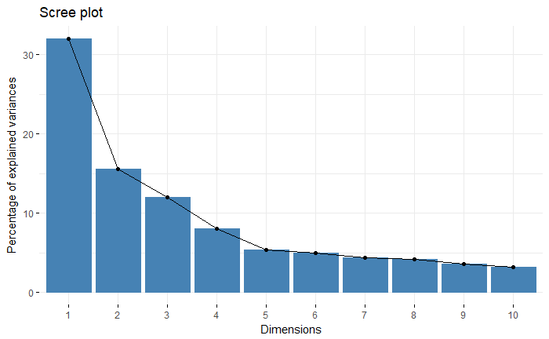

```r
pcares <- prcomp(bptrain[,1:14])
fviz_eig(pcares)
```

The first 9 PCs are enough to tackle 90% of the variance it seems.  
So lets look at their correlations - highly positively correlated values point in the same directions, whereas negatively correlated variables point in opposite directions.

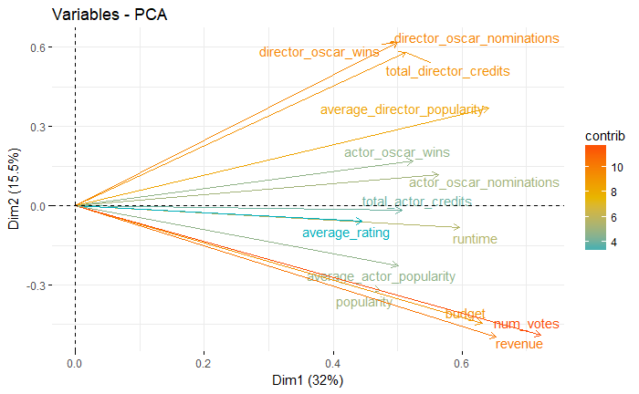

```r
fviz_pca_var(pcares,
             col.var = "contrib", # Color by contributions to the PC
             gradient.cols = c("#00AFBB", "#E7B800", "#FC4E07"),
             repel = TRUE     # Avoid text overlapping
             )
```

So, it seems that everything is positively correlated to varying degrees.

lets take a look at the actual eigenvalues:

```r
get_eigenvalue(pcares)
```

|  | eigenvalue | variance.percent | cumulative.variance.percent |
| --- | --- | --- | --- |
| Dim.1 | 4.3980501 | 32.044265 | 32.04427 |
| Dim.2 | 2.1341556 | 15.549493 | 47.59376 |
| Dim.3 | 1.6513550 | 12.031800 | 59.62556 |
| Dim.4 | 1.1023354 | 8.031634 | 67.65719 |
| Dim.5 | 0.7428003 | 5.412055 | 73.06925 |
| Dim.6 | 0.6792963 | 4.949364 | 78.01861 |
| Dim.7 | 0.6043654 | 4.403416 | 82.42203 |
| Dim.8 | 0.5738129 | 4.180810 | 86.60284 |
| Dim.9 | 0.4896258 | 3.567422 | 90.17026 |
| Dim.10 | 0.4373346 | 3.186427 | 93.35669 |

[output cut: 4 more lines]

So, yeah, 9 or 10 dimensions gets really good accuracy according to the variance percentages. We’ll make use of this information going forward.

We’ll begin with an analysis of hte best pictures category, beginning with a logistic regression. Remember, for our purposes, nomination and victory are mutually exclusive for our purposes.

```r
logmodbpnom <- glm(nominee~.-winner, data = bptrain, family = binomial)
summary(logmodbpnom)
```

```
Call:
glm(formula = nominee ~ . - winner, family = binomial, data = bptrain)

Deviance Residuals:
     Min        1Q    Median        3Q       Max
-3.04645  -0.17730  -0.08645  -0.04156   2.97139

Coefficients:
                            Estimate Std. Error z value Pr(>|z|)
(Intercept)                 -5.24736    0.33172 -15.819  < 2e-16 ***
budget                      -0.56341    0.24266  -2.322  0.02024 *
revenue                      0.25983    0.17534   1.482  0.13838
runtime                      0.11694    0.14533   0.805  0.42104
popularity                   0.22725    0.16269   1.397  0.16246
average_rating               1.73908    0.25730   6.759 1.39e-11 ***
num_votes                    0.24001    0.15692   1.529  0.12615
total_actor_credits         -0.29373    0.16892  -1.739  0.08205 .
average_actor_popularity    -0.14331    0.16673  -0.860  0.39004
actor_oscar_nominations     -0.04153    0.16537  -0.251  0.80172
actor_oscar_wins             0.36567    0.16190   2.259  0.02390 *
total_director_credits      -0.57058    0.20090  -2.840  0.00451 **
average_director_popularity -0.18133    0.14549  -1.246  0.21264
director_oscar_nominations   0.79474    0.11826   6.721 1.81e-11 ***
director_oscar_wins          0.32845    0.10101   3.252  0.00115 **
---
Signif. codes:  0 ‘***’ 0.001 ‘**’ 0.01 ‘*’ 0.05 ‘.’ 0.1 ‘ ’ 1

(Dispersion parameter for binomial family taken to be 1)

    Null deviance: 710.59  on 2012  degrees of freedom
Residual deviance: 398.02  on 1998  degrees of freedom
AIC: 428.02

Number of Fisher Scoring iterations: 8
```

So immediately we see we have some tuning to do, as there are a lot of variables with p > .05. Lets start doing some backwards elimination:

```r
logmodbpnom <- glm(nominee~.-winner-actor_oscar_nominations, data = bptrain, family = binomial)
summary(logmodbpnom)
```

```
Call:
glm(formula = nominee ~ . - winner - actor_oscar_nominations,
    family = binomial, data = bptrain)

Deviance Residuals:
     Min        1Q    Median        3Q       Max
-3.07337  -0.17675  -0.08600  -0.04153   2.97014

Coefficients:
                            Estimate Std. Error z value Pr(>|z|)
(Intercept)                  -5.2499     0.3320 -15.813  < 2e-16 ***
budget                       -0.5635     0.2429  -2.320  0.02032 *
revenue                       0.2599     0.1753   1.482  0.13829
runtime                       0.1190     0.1450   0.821  0.41189
popularity                    0.2253     0.1630   1.382  0.16710
average_rating                1.7374     0.2574   6.751 1.47e-11 ***
num_votes                     0.2401     0.1569   1.530  0.12602
total_actor_credits          -0.3041     0.1640  -1.854  0.06373 .
average_actor_popularity     -0.1470     0.1662  -0.884  0.37643
actor_oscar_wins              0.3398     0.1250   2.718  0.00656 **
total_director_credits       -0.5691     0.2006  -2.837  0.00456 **
average_director_popularity  -0.1791     0.1452  -1.233  0.21758
director_oscar_nominations    0.7923     0.1177   6.733 1.66e-11 ***
director_oscar_wins           0.3272     0.1009   3.244  0.00118 **
---
Signif. codes:  0 ‘***’ 0.001 ‘**’ 0.01 ‘*’ 0.05 ‘.’ 0.1 ‘ ’ 1

(Dispersion parameter for binomial family taken to be 1)

    Null deviance: 710.59  on 2012  degrees of freedom
Residual deviance: 398.08  on 1999  degrees of freedom
AIC: 426.08

Number of Fisher Scoring iterations: 8
```

```r
logmodbpnom <- glm(nominee~.-winner-actor_oscar_nominations-runtime, data = bptrain, family = binomial)
summary(logmodbpnom)
```

```
Call:
glm(formula = nominee ~ . - winner - actor_oscar_nominations -
    runtime, family = binomial, data = bptrain)

Deviance Residuals:
     Min        1Q    Median        3Q       Max
-3.06603  -0.17783  -0.08539  -0.04089   2.97104

Coefficients:
                            Estimate Std. Error z value Pr(>|z|)
(Intercept)                  -5.2518     0.3330 -15.773  < 2e-16 ***
budget                       -0.5188     0.2349  -2.208  0.02721 *
revenue                       0.2685     0.1740   1.543  0.12287
popularity                    0.2142     0.1623   1.320  0.18697
average_rating                1.8084     0.2431   7.440 1.01e-13 ***
num_votes                     0.2307     0.1556   1.483  0.13816
total_actor_credits          -0.2951     0.1627  -1.814  0.06971 .
average_actor_popularity     -0.1442     0.1641  -0.879  0.37942
actor_oscar_wins              0.3411     0.1244   2.742  0.00611 **
total_director_credits       -0.5693     0.2009  -2.834  0.00460 **
average_director_popularity  -0.1565     0.1419  -1.103  0.26989
director_oscar_nominations    0.7900     0.1180   6.698 2.11e-11 ***
director_oscar_wins           0.3282     0.1008   3.256  0.00113 **
---
Signif. codes:  0 ‘***’ 0.001 ‘**’ 0.01 ‘*’ 0.05 ‘.’ 0.1 ‘ ’ 1

(Dispersion parameter for binomial family taken to be 1)

    Null deviance: 710.59  on 2012  degrees of freedom
Residual deviance: 398.73  on 2000  degrees of freedom
AIC: 424.73

Number of Fisher Scoring iterations: 8
```

```r
logmodbpnom <- glm(nominee~.-winner-actor_oscar_nominations-runtime-average_actor_popularity, data = bptrain, family = binomial)
summary(logmodbpnom)
```

```
Call:
glm(formula = nominee ~ . - winner - actor_oscar_nominations -
    runtime - average_actor_popularity, family = binomial, data = bptrain)

Deviance Residuals:
     Min        1Q    Median        3Q       Max
-3.09783  -0.17659  -0.08394  -0.04007   3.03388

Coefficients:
                            Estimate Std. Error z value Pr(>|z|)
(Intercept)                  -5.2649     0.3332 -15.800  < 2e-16 ***
budget                       -0.5418     0.2333  -2.322  0.02021 *
revenue                       0.2789     0.1735   1.608  0.10786
popularity                    0.1971     0.1611   1.223  0.22136
average_rating                1.8122     0.2423   7.480 7.41e-14 ***
num_votes                     0.2076     0.1530   1.357  0.17477
total_actor_credits          -0.3194     0.1616  -1.977  0.04807 *
actor_oscar_wins              0.3361     0.1243   2.703  0.00687 **
total_director_credits       -0.5745     0.2009  -2.860  0.00423 **
average_director_popularity  -0.1538     0.1418  -1.085  0.27788
director_oscar_nominations    0.7971     0.1183   6.740 1.58e-11 ***
director_oscar_wins           0.3250     0.1006   3.230  0.00124 **
---
Signif. codes:  0 ‘***’ 0.001 ‘**’ 0.01 ‘*’ 0.05 ‘.’ 0.1 ‘ ’ 1

(Dispersion parameter for binomial family taken to be 1)

    Null deviance: 710.59  on 2012  degrees of freedom
Residual deviance: 399.51  on 2001  degrees of freedom
AIC: 423.51

Number of Fisher Scoring iterations: 8
```

```r
logmodbpnom <- glm(nominee~.-winner-actor_oscar_nominations-runtime-average_actor_popularity-average_director_popularity, data = bptrain, family = binomial)
summary(logmodbpnom)
```

```
Call:
glm(formula = nominee ~ . - winner - actor_oscar_nominations -
    runtime - average_actor_popularity - average_director_popularity,
    family = binomial, data = bptrain)

Deviance Residuals:
     Min        1Q    Median        3Q       Max
-2.99245  -0.17675  -0.08464  -0.04112   3.01385

Coefficients:
                           Estimate Std. Error z value Pr(>|z|)
(Intercept)                -5.25367    0.33128 -15.859  < 2e-16 ***
budget                     -0.56942    0.23164  -2.458 0.013962 *
revenue                     0.30175    0.17157   1.759 0.078625 .
popularity                  0.17859    0.16309   1.095 0.273476
average_rating              1.79868    0.24160   7.445 9.69e-14 ***
num_votes                   0.18582    0.15222   1.221 0.222180
total_actor_credits        -0.32449    0.16031  -2.024 0.042962 *
actor_oscar_wins            0.33063    0.12352   2.677 0.007432 **
total_director_credits     -0.64447    0.19327  -3.335 0.000854 ***
director_oscar_nominations  0.79320    0.11850   6.694 2.18e-11 ***
director_oscar_wins         0.28656    0.09437   3.036 0.002394 **
---
Signif. codes:  0 ‘***’ 0.001 ‘**’ 0.01 ‘*’ 0.05 ‘.’ 0.1 ‘ ’ 1

(Dispersion parameter for binomial family taken to be 1)

    Null deviance: 710.59  on 2012  degrees of freedom
Residual deviance: 400.73  on 2002  degrees of freedom
AIC: 422.73

Number of Fisher Scoring iterations: 8
```

```r
logmodbpnom <- glm(nominee~.-winner-actor_oscar_nominations-runtime-average_actor_popularity-average_director_popularity-popularity, data = bptrain, family = binomial)
summary(logmodbpnom)
```

```
Call:
glm(formula = nominee ~ . - winner - actor_oscar_nominations -
    runtime - average_actor_popularity - average_director_popularity -
    popularity, family = binomial, data = bptrain)

Deviance Residuals:
     Min        1Q    Median        3Q       Max
-3.04899  -0.17835  -0.08647  -0.04127   2.97666

Coefficients:
                           Estimate Std. Error z value Pr(>|z|)
(Intercept)                 -5.2464     0.3308 -15.859  < 2e-16 ***
budget                      -0.5291     0.2280  -2.320 0.020327 *
revenue                      0.3070     0.1739   1.765 0.077578 .
average_rating               1.8261     0.2413   7.569 3.75e-14 ***
num_votes                    0.2371     0.1474   1.608 0.107763
total_actor_credits         -0.3306     0.1601  -2.065 0.038891 *
actor_oscar_wins             0.3323     0.1233   2.695 0.007040 **
total_director_credits      -0.6392     0.1925  -3.320 0.000899 ***
director_oscar_nominations   0.7929     0.1183   6.701 2.07e-11 ***
director_oscar_wins          0.2831     0.0942   3.006 0.002650 **
---
Signif. codes:  0 ‘***’ 0.001 ‘**’ 0.01 ‘*’ 0.05 ‘.’ 0.1 ‘ ’ 1

(Dispersion parameter for binomial family taken to be 1)

    Null deviance: 710.59  on 2012  degrees of freedom
Residual deviance: 401.79  on 2003  degrees of freedom
AIC: 421.79

Number of Fisher Scoring iterations: 8
```

```r
logmodbpnom <- glm(nominee~.-winner-actor_oscar_nominations-runtime-average_actor_popularity-average_director_popularity-popularity-num_votes, data = bptrain, family = binomial)
summary(logmodbpnom)
```

```
Call:
glm(formula = nominee ~ . - winner - actor_oscar_nominations -
    runtime - average_actor_popularity - average_director_popularity -
    popularity - num_votes, family = binomial, data = bptrain)

Deviance Residuals:
     Min        1Q    Median        3Q       Max
-2.89578  -0.17876  -0.08225  -0.03842   2.89024

Coefficients:
                           Estimate Std. Error z value Pr(>|z|)
(Intercept)                -5.31815    0.33483 -15.883  < 2e-16 ***
budget                     -0.46693    0.22292  -2.095  0.03620 *
revenue                     0.44789    0.15403   2.908  0.00364 **
average_rating              2.00489    0.21860   9.172  < 2e-16 ***
total_actor_credits        -0.29617    0.15729  -1.883  0.05971 .
actor_oscar_wins            0.32758    0.12193   2.687  0.00722 **
total_director_credits     -0.62545    0.19074  -3.279  0.00104 **
director_oscar_nominations  0.78575    0.11782   6.669 2.58e-11 ***
director_oscar_wins         0.26955    0.09291   2.901  0.00372 **
---
Signif. codes:  0 ‘***’ 0.001 ‘**’ 0.01 ‘*’ 0.05 ‘.’ 0.1 ‘ ’ 1

(Dispersion parameter for binomial family taken to be 1)

    Null deviance: 710.59  on 2012  degrees of freedom
Residual deviance: 404.39  on 2004  degrees of freedom
AIC: 422.39

Number of Fisher Scoring iterations: 8
```

```r
logmodbpnom <- glm(nominee~.-winner-actor_oscar_nominations-runtime-average_actor_popularity-average_director_popularity-popularity-num_votes-total_actor_credits, data = bptrain, family = binomial)
summary(logmodbpnom)
```

```
Call:
glm(formula = nominee ~ . - winner - actor_oscar_nominations -
    runtime - average_actor_popularity - average_director_popularity -
    popularity - num_votes - total_actor_credits, family = binomial,
    data = bptrain)

Deviance Residuals:
     Min        1Q    Median        3Q       Max
-2.99114  -0.18108  -0.08468  -0.04022   2.88759

Coefficients:
                           Estimate Std. Error z value Pr(>|z|)
(Intercept)                -5.25687    0.32857 -15.999  < 2e-16 ***
budget                     -0.51068    0.22386  -2.281 0.022533 *
revenue                     0.41864    0.15374   2.723 0.006469 **
average_rating              1.99628    0.21678   9.209  < 2e-16 ***
actor_oscar_wins            0.22421    0.10733   2.089 0.036702 *
total_director_credits     -0.66712    0.18985  -3.514 0.000441 ***
director_oscar_nominations  0.76991    0.11728   6.565  5.2e-11 ***
director_oscar_wins         0.29626    0.09168   3.231 0.001232 **
---
Signif. codes:  0 ‘***’ 0.001 ‘**’ 0.01 ‘*’ 0.05 ‘.’ 0.1 ‘ ’ 1

(Dispersion parameter for binomial family taken to be 1)

    Null deviance: 710.59  on 2012  degrees of freedom
Residual deviance: 408.16  on 2005  degrees of freedom
AIC: 424.16

Number of Fisher Scoring iterations: 8
```

All remaining variables now have p-values below .05, so this model should be ideal. And look, just 7 variables remain in the final model! Lets try to make some predictions with this now:

```r
bpnompreds <- predict(logmodbpnom, newdata = bptest, type = "response")
```

Lets check the confusion matrix for this at, say a .5 cutoff.

```r
table(bptest$nominee, bpnompreds > 0.5)
```

```
    FALSE TRUE
  0   485    5
  1     8    6
```

So, a lot of false negatives, but its still a 97% accuracy. Maybe we try a lower cutoff?

```r
table(bptest$nominee, bpnompreds > 0.1)
```

```
    FALSE TRUE
  0   466   24
  1     4   10
```

Better at correctly predicting nominees, but worse overall… this one gave nominations to 24 movies that weren’t nominated. Let’s check the ROC:

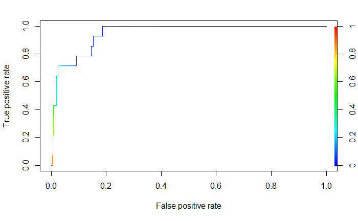

```r
rocpred <- prediction(bpnompreds, bptest$nominee)
rocperf <- performance(rocpred, 'tpr', 'fpr')
plot(rocperf, colorize = TRUE, text.adj = c(-.2, 1.7))
```

```r
performance(rocpred, 'auc')
```

```
An object of class "performance"
Slot "x.name":
[1] "None"

Slot "y.name":
[1] "Area under the ROC curve"

Slot "alpha.name":
[1] "none"

Slot "x.values":
list()

Slot "y.values":
[[1]]
[1] 0.9502915


Slot "alpha.values":
list()
```

Lets try the same thing for the winners:

```r
logmodbpwin <- glm(winner~.-nominee, data = bptrain, family = binomial)
```

```
glm.fit: fitted probabilities numerically 0 or 1 occurred
```

```r
summary(logmodbpwin)
```

```
Call:
glm(formula = winner ~ . - nominee, family = binomial, data = bptrain)

Deviance Residuals:
     Min        1Q    Median        3Q       Max
-1.57373  -0.01926  -0.00469  -0.00075   3.00942

Coefficients:
                            Estimate Std. Error z value Pr(>|z|)
(Intercept)                 -12.5740     2.8451  -4.420 9.89e-06 ***
budget                       -6.9647     2.8010  -2.487  0.01290 *
revenue                       2.1553     0.8333   2.586  0.00970 **
runtime                       0.1596     0.5168   0.309  0.75740
popularity                    0.4627     0.9199   0.503  0.61495
average_rating                2.3882     1.1360   2.102  0.03553 *
num_votes                    -0.2804     0.6418  -0.437  0.66215
total_actor_credits           1.0548     0.3970   2.657  0.00788 **
average_actor_popularity      0.2302     0.4378   0.526  0.59902
actor_oscar_nominations       0.4006     0.7163   0.559  0.57599
actor_oscar_wins             -0.7877     0.6688  -1.178  0.23891
total_director_credits       -1.1900     0.8092  -1.471  0.14142
average_director_popularity   0.1493     0.3654   0.409  0.68280
director_oscar_nominations    0.6193     0.4490   1.379  0.16781
director_oscar_wins           0.5500     0.2655   2.071  0.03834 *
---
Signif. codes:  0 ‘***’ 0.001 ‘**’ 0.01 ‘*’ 0.05 ‘.’ 0.1 ‘ ’ 1

(Dispersion parameter for binomial family taken to be 1)

    Null deviance: 115.343  on 2012  degrees of freedom
Residual deviance:  51.233  on 1998  degrees of freedom
AIC: 81.233

Number of Fisher Scoring iterations: 12
```

Oh boy, time for a lot of back propogation! Only 5 variables are below p=.05.

```r
logmodbpwin <- glm(winner~.-nominee-runtime, data = bptrain, family = binomial)
```

```
glm.fit: fitted probabilities numerically 0 or 1 occurred
```

```r
summary(logmodbpwin)
```

```
Call:
glm(formula = winner ~ . - nominee - runtime, family = binomial,
    data = bptrain)

Deviance Residuals:
     Min        1Q    Median        3Q       Max
-1.52928  -0.01935  -0.00463  -0.00075   3.02554

Coefficients:
                            Estimate Std. Error z value Pr(>|z|)
(Intercept)                 -12.4565     2.7886  -4.467 7.93e-06 ***
budget                       -6.6360     2.5128  -2.641  0.00827 **
revenue                       2.1952     0.8182   2.683  0.00730 **
popularity                    0.4713     0.9013   0.523  0.60105
average_rating                2.5145     1.0672   2.356  0.01847 *
num_votes                    -0.3329     0.6094  -0.546  0.58490
total_actor_credits           1.0519     0.3934   2.674  0.00750 **
average_actor_popularity      0.2254     0.4373   0.515  0.60630
actor_oscar_nominations       0.4136     0.7071   0.585  0.55861
actor_oscar_wins             -0.8030     0.6609  -1.215  0.22435
total_director_credits       -1.1896     0.8175  -1.455  0.14560
average_director_popularity   0.1492     0.3649   0.409  0.68267
director_oscar_nominations    0.6187     0.4531   1.365  0.17212
director_oscar_wins           0.5503     0.2627   2.095  0.03620 *
---
Signif. codes:  0 ‘***’ 0.001 ‘**’ 0.01 ‘*’ 0.05 ‘.’ 0.1 ‘ ’ 1

(Dispersion parameter for binomial family taken to be 1)

    Null deviance: 115.343  on 2012  degrees of freedom
Residual deviance:  51.328  on 1999  degrees of freedom
AIC: 79.328

Number of Fisher Scoring iterations: 12
```

```r
logmodbpwin <- glm(winner~.-nominee-runtime-average_director_popularity, data = bptrain, family = binomial)
```

```
glm.fit: fitted probabilities numerically 0 or 1 occurred
```

```r
summary(logmodbpwin)
```

```
Call:
glm(formula = winner ~ . - nominee - runtime - average_director_popularity,
    family = binomial, data = bptrain)

Deviance Residuals:
     Min        1Q    Median        3Q       Max
-1.59319  -0.02085  -0.00515  -0.00090   2.97900

Coefficients:
                           Estimate Std. Error z value Pr(>|z|)
(Intercept)                -12.2099     2.6091  -4.680 2.87e-06 ***
budget                      -6.4906     2.4574  -2.641  0.00826 **
revenue                      2.1960     0.8320   2.639  0.00831 **
popularity                   0.5341     0.8331   0.641  0.52142
average_rating               2.4431     1.0155   2.406  0.01614 *
num_votes                   -0.3600     0.5965  -0.604  0.54614
total_actor_credits          1.0456     0.3936   2.656  0.00790 **
average_actor_popularity     0.1969     0.4380   0.449  0.65308
actor_oscar_nominations      0.3541     0.6929   0.511  0.60928
actor_oscar_wins            -0.7508     0.6489  -1.157  0.24723
total_director_credits      -1.1096     0.7978  -1.391  0.16430
director_oscar_nominations   0.6240     0.4448   1.403  0.16068
director_oscar_wins          0.5778     0.2548   2.268  0.02333 *
---
Signif. codes:  0 ‘***’ 0.001 ‘**’ 0.01 ‘*’ 0.05 ‘.’ 0.1 ‘ ’ 1

(Dispersion parameter for binomial family taken to be 1)

    Null deviance: 115.34  on 2012  degrees of freedom
Residual deviance:  51.49  on 2000  degrees of freedom
AIC: 77.49

Number of Fisher Scoring iterations: 12
```

```r
logmodbpwin <- glm(winner~.-nominee-runtime-average_director_popularity-average_actor_popularity, data = bptrain, family = binomial)
```

```
glm.fit: fitted probabilities numerically 0 or 1 occurred
```

```r
summary(logmodbpwin)
```

```
Call:
glm(formula = winner ~ . - nominee - runtime - average_director_popularity -
    average_actor_popularity, family = binomial, data = bptrain)

Deviance Residuals:
     Min        1Q    Median        3Q       Max
-1.55170  -0.02125  -0.00528  -0.00095   3.00259

Coefficients:
                           Estimate Std. Error z value Pr(>|z|)
(Intercept)                -12.1153     2.5663  -4.721 2.35e-06 ***
budget                      -6.3898     2.4266  -2.633  0.00846 **
revenue                      2.1876     0.8254   2.650  0.00804 **
popularity                   0.5005     0.8529   0.587  0.55737
average_rating               2.4283     1.0109   2.402  0.01629 *
num_votes                   -0.3209     0.5890  -0.545  0.58589
total_actor_credits          1.0249     0.3826   2.679  0.00739 **
actor_oscar_nominations      0.4295     0.6444   0.667  0.50503
actor_oscar_wins            -0.7478     0.6507  -1.149  0.25047
total_director_credits      -1.0747     0.7721  -1.392  0.16395
director_oscar_nominations   0.6088     0.4345   1.401  0.16120
director_oscar_wins          0.5646     0.2495   2.263  0.02365 *
---
Signif. codes:  0 ‘***’ 0.001 ‘**’ 0.01 ‘*’ 0.05 ‘.’ 0.1 ‘ ’ 1

(Dispersion parameter for binomial family taken to be 1)

    Null deviance: 115.343  on 2012  degrees of freedom
Residual deviance:  51.676  on 2001  degrees of freedom
AIC: 75.676

Number of Fisher Scoring iterations: 12
```

```r
logmodbpwin <- glm(winner~.-nominee-runtime-average_director_popularity-average_actor_popularity-num_votes, data = bptrain, family = binomial)
```

```
glm.fit: fitted probabilities numerically 0 or 1 occurred
```

```r
summary(logmodbpwin)
```

```
Call:
glm(formula = winner ~ . - nominee - runtime - average_director_popularity -
    average_actor_popularity - num_votes, family = binomial,
    data = bptrain)

Deviance Residuals:
     Min        1Q    Median        3Q       Max
-1.52810  -0.02344  -0.00634  -0.00123   3.00549

Coefficients:
                           Estimate Std. Error z value Pr(>|z|)
(Intercept)                -11.7957     2.3744  -4.968 6.77e-07 ***
budget                      -6.3267     2.3642  -2.676  0.00745 **
revenue                      2.0093     0.7363   2.729  0.00636 **
popularity                   0.2569     0.8234   0.312  0.75502
average_rating               2.1551     0.8511   2.532  0.01134 *
total_actor_credits          0.9987     0.3736   2.673  0.00751 **
actor_oscar_nominations      0.3987     0.6409   0.622  0.53392
actor_oscar_wins            -0.7396     0.6528  -1.133  0.25727
total_director_credits      -1.0784     0.7733  -1.395  0.16315
director_oscar_nominations   0.5918     0.4312   1.373  0.16990
director_oscar_wins          0.5926     0.2433   2.435  0.01488 *
---
Signif. codes:  0 ‘***’ 0.001 ‘**’ 0.01 ‘*’ 0.05 ‘.’ 0.1 ‘ ’ 1

(Dispersion parameter for binomial family taken to be 1)

    Null deviance: 115.343  on 2012  degrees of freedom
Residual deviance:  51.973  on 2002  degrees of freedom
AIC: 73.973

Number of Fisher Scoring iterations: 12
```

```r
logmodbpwin <- glm(winner~.-nominee-runtime-average_director_popularity-average_actor_popularity-num_votes-popularity, data = bptrain, family = binomial)
```

```
glm.fit: fitted probabilities numerically 0 or 1 occurred
```

```r
summary(logmodbpwin)
```

```
Call:
glm(formula = winner ~ . - nominee - runtime - average_director_popularity -
    average_actor_popularity - num_votes - popularity, family = binomial,
    data = bptrain)

Deviance Residuals:
     Min        1Q    Median        3Q       Max
-1.51443  -0.02353  -0.00614  -0.00118   3.06513

Coefficients:
                           Estimate Std. Error z value Pr(>|z|)
(Intercept)                -11.8201     2.3727  -4.982  6.3e-07 ***
budget                      -6.2741     2.3638  -2.654  0.00795 **
revenue                      2.0744     0.7162   2.896  0.00378 **
average_rating               2.2516     0.8010   2.811  0.00494 **
total_actor_credits          0.9984     0.3731   2.676  0.00745 **
actor_oscar_nominations      0.3767     0.6329   0.595  0.55168
actor_oscar_wins            -0.7091     0.6361  -1.115  0.26491
total_director_credits      -1.0867     0.7744  -1.403  0.16052
director_oscar_nominations   0.6078     0.4287   1.418  0.15626
director_oscar_wins          0.5809     0.2391   2.429  0.01513 *
---
Signif. codes:  0 ‘***’ 0.001 ‘**’ 0.01 ‘*’ 0.05 ‘.’ 0.1 ‘ ’ 1

(Dispersion parameter for binomial family taken to be 1)

    Null deviance: 115.343  on 2012  degrees of freedom
Residual deviance:  52.063  on 2003  degrees of freedom
AIC: 72.063

Number of Fisher Scoring iterations: 12
```

```r
logmodbpwin <- glm(winner~.-nominee-runtime-average_director_popularity-average_actor_popularity-num_votes-popularity-actor_oscar_nominations, data = bptrain, family = binomial)
```

```
glm.fit: fitted probabilities numerically 0 or 1 occurred
```

```r
summary(logmodbpwin)
```

```
Call:
glm(formula = winner ~ . - nominee - runtime - average_director_popularity -
    average_actor_popularity - num_votes - popularity - actor_oscar_nominations,
    family = binomial, data = bptrain)

Deviance Residuals:
     Min        1Q    Median        3Q       Max
-1.32591  -0.02474  -0.00676  -0.00136   3.05448

Coefficients:
                           Estimate Std. Error z value Pr(>|z|)
(Intercept)                -11.5609     2.2474  -5.144 2.69e-07 ***
budget                      -5.9256     2.2572  -2.625  0.00866 **
revenue                      2.0147     0.7067   2.851  0.00436 **
average_rating               2.2417     0.7842   2.858  0.00426 **
total_actor_credits          1.0401     0.3596   2.892  0.00383 **
actor_oscar_wins            -0.5030     0.5099  -0.986  0.32394
total_director_credits      -1.1953     0.7718  -1.549  0.12146
director_oscar_nominations   0.6567     0.4312   1.523  0.12772
director_oscar_wins          0.5833     0.2343   2.489  0.01281 *
---
Signif. codes:  0 ‘***’ 0.001 ‘**’ 0.01 ‘*’ 0.05 ‘.’ 0.1 ‘ ’ 1

(Dispersion parameter for binomial family taken to be 1)

    Null deviance: 115.343  on 2012  degrees of freedom
Residual deviance:  52.401  on 2004  degrees of freedom
AIC: 70.401

Number of Fisher Scoring iterations: 11
```

```r
logmodbpwin <- glm(winner~.-nominee-runtime-average_director_popularity-average_actor_popularity-num_votes-popularity-actor_oscar_nominations-actor_oscar_wins, data = bptrain, family = binomial)
```

```
glm.fit: fitted probabilities numerically 0 or 1 occurred
```

```r
summary(logmodbpwin)
```

```
Call:
glm(formula = winner ~ . - nominee - runtime - average_director_popularity -
    average_actor_popularity - num_votes - popularity - actor_oscar_nominations -
    actor_oscar_wins, family = binomial, data = bptrain)

Deviance Residuals:
     Min        1Q    Median        3Q       Max
-1.20480  -0.02470  -0.00668  -0.00135   3.10277

Coefficients:
                           Estimate Std. Error z value Pr(>|z|)
(Intercept)                -11.5974     2.2280  -5.205 1.94e-07 ***
budget                      -6.1824     2.2453  -2.753  0.00590 **
revenue                      2.1685     0.7106   3.052  0.00228 **
average_rating               2.2451     0.7830   2.867  0.00414 **
total_actor_credits          0.9607     0.3659   2.626  0.00865 **
total_director_credits      -1.0851     0.7232  -1.500  0.13352
director_oscar_nominations   0.5852     0.4286   1.365  0.17217
director_oscar_wins          0.4948     0.2087   2.371  0.01775 *
---
Signif. codes:  0 ‘***’ 0.001 ‘**’ 0.01 ‘*’ 0.05 ‘.’ 0.1 ‘ ’ 1

(Dispersion parameter for binomial family taken to be 1)

    Null deviance: 115.343  on 2012  degrees of freedom
Residual deviance:  53.539  on 2005  degrees of freedom
AIC: 69.539

Number of Fisher Scoring iterations: 11
```

```r
logmodbpwin <- glm(winner~.-nominee-runtime-average_director_popularity-average_actor_popularity-num_votes-popularity-actor_oscar_nominations-actor_oscar_wins-director_oscar_nominations, data = bptrain, family = binomial)
```

```
glm.fit: fitted probabilities numerically 0 or 1 occurred
```

```r
summary(logmodbpwin)
```

```
Call:
glm(formula = winner ~ . - nominee - runtime - average_director_popularity -
    average_actor_popularity - num_votes - popularity - actor_oscar_nominations -
    actor_oscar_wins - director_oscar_nominations, family = binomial,
    data = bptrain)

Deviance Residuals:
    Min       1Q   Median       3Q      Max
-1.0743  -0.0316  -0.0097  -0.0021   3.2317

Coefficients:
                       Estimate Std. Error z value Pr(>|z|)
(Intercept)            -11.0323     2.0196  -5.463 4.69e-08 ***
budget                  -6.3089     2.3220  -2.717  0.00659 **
revenue                  2.1372     0.7346   2.909  0.00362 **
average_rating           1.9916     0.7050   2.825  0.00473 **
total_actor_credits      0.9634     0.3603   2.674  0.00750 **
total_director_credits  -0.4807     0.5373  -0.895  0.37095
director_oscar_wins      0.4995     0.2055   2.431  0.01508 *
---
Signif. codes:  0 ‘***’ 0.001 ‘**’ 0.01 ‘*’ 0.05 ‘.’ 0.1 ‘ ’ 1

(Dispersion parameter for binomial family taken to be 1)

    Null deviance: 115.343  on 2012  degrees of freedom
Residual deviance:  55.177  on 2006  degrees of freedom
AIC: 69.177

Number of Fisher Scoring iterations: 11
```

```r
logmodbpwin <- glm(winner~.-nominee-runtime-average_director_popularity-average_actor_popularity-num_votes-popularity-actor_oscar_nominations-actor_oscar_wins-director_oscar_nominations-total_director_credits, data = bptrain, family = binomial)
```

```
glm.fit: fitted probabilities numerically 0 or 1 occurred
```

```r
summary(logmodbpwin)
```

```
Call:
glm(formula = winner ~ . - nominee - runtime - average_director_popularity -
    average_actor_popularity - num_votes - popularity - actor_oscar_nominations -
    actor_oscar_wins - director_oscar_nominations - total_director_credits,
    family = binomial, data = bptrain)

Deviance Residuals:
    Min       1Q   Median       3Q      Max
-1.0748  -0.0301  -0.0087  -0.0016   3.2059

Coefficients:
                    Estimate Std. Error z value Pr(>|z|)
(Intercept)         -11.4269     2.0733  -5.511 3.56e-08 ***
budget               -7.0560     2.2508  -3.135  0.00172 **
revenue               2.3092     0.7099   3.253  0.00114 **
average_rating        1.9469     0.6983   2.788  0.00530 **
total_actor_credits   0.8957     0.3419   2.620  0.00879 **
director_oscar_wins   0.4139     0.1837   2.253  0.02426 *
---
Signif. codes:  0 ‘***’ 0.001 ‘**’ 0.01 ‘*’ 0.05 ‘.’ 0.1 ‘ ’ 1

(Dispersion parameter for binomial family taken to be 1)

    Null deviance: 115.343  on 2012  degrees of freedom
Residual deviance:  56.119  on 2007  degrees of freedom
AIC: 68.119

Number of Fisher Scoring iterations: 11
```

```r
bpwinpreds <- predict(logmodbpwin, newdata = bptest, type = "response")
```

Lets start with the confusion matrix again:

```r
table(bptest$winner, bpwinpreds > .5)
```

```
    FALSE
  0   498
  1     6
```

Oh joy. Lets turn that cutoff down:

```r
table(bptest$winner, bpwinpreds > .04)
```

```
    FALSE TRUE
  0   495    3
  1     4    2
```

Fun fact, that first confusion matrix has an accuracy of 99% despite being utter nonsense. This latest one is much better about actually predicting winners and also has an accuracy of 99%. Looking at the ROC and AUC:

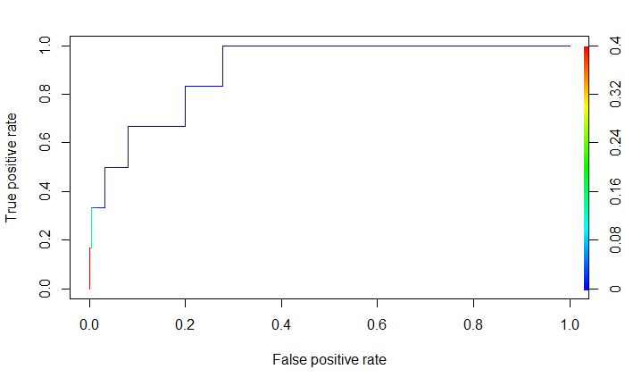

```r
rocpred <- prediction(bpwinpreds, bptest$winner)
rocperf <- performance(rocpred, 'tpr', 'fpr')
plot(rocperf, colorize = TRUE, text.adj = c(-.2, 1.7))
```

```r
performance(rocpred, 'auc')
```

```
An object of class "performance"
Slot "x.name":
[1] "None"

Slot "y.name":
[1] "Area under the ROC curve"

Slot "alpha.name":
[1] "none"

Slot "x.values":
list()

Slot "y.values":
[[1]]
[1] 0.9012718


Slot "alpha.values":
list()
```

Once again, AUC is .9. Im starting to think that using logistic regression was just a bad idea - its too extreme. Maybe and SVM will do better?

Lets try it! Code is adapted from http://dataaspirant.com/2017/01/19/support-vector-machine-classifier-implementation-r-caret-package/

```r
trctrl <- trainControl(method = "repeatedcv", number = 10, repeats = 3)
bptrain$nominee <- as.factor(bptrain$nominee)
bptest$nominee <- as.factor(bptest$nominee)
bptrain$winner <- as.factor(bptrain$winner)
bptest$winner <- as.factor(bptest$winner)
svmbpnom <- train(nominee ~.-winner, data = bptrain, method = "svmLinear",
                 trControl=trctrl,
                 preProcess = c("center", "scale"),
                 tuneLength = 10)
svmbpnom
```

```
Support Vector Machines with Linear Kernel

2013 samples
  15 predictor
   2 classes: '0', '1'

Pre-processing: centered (14), scaled (14)
Resampling: Cross-Validated (10 fold, repeated 3 times)
Summary of sample sizes: 1812, 1811, 1812, 1811, 1812, 1811, ...
Resampling results:

  Accuracy   Kappa
  0.9564535  -0.001338367

Tuning parameter 'C' was held constant at a value of 1
```

Looking good so far. Lets try to predict now:

```r
svmbpnompred <- predict(svmbpnom, newdata = bptest)
svmbpnompred
```

```
  [1] 0 0 0 0 0 0 0 0 0 0 0 0 0 0 0 0 0 0 0 0 0 0 0 0 0 0 0 0 0 0 0 0 0 0 0 0 0 0 0 0 0 0 0 0 0 0 0 0 0 0 0 0 0 0 0 0 0 0 0 0 0 0 0 0 0 0 0 0 0
 [70] 0 0 0 0 0 0 0 0 0 0 0 0 0 0 0 0 0 0 0 0 0 0 0 0 0 0 0 0 0 0 0 0 0 0 0 0 0 0 0 0 0 0 0 0 0 0 0 0 0 0 0 0 0 0 0 0 0 0 0 0 0 0 0 0 0 0 0 0 0
[139] 0 0 0 0 0 0 0 0 0 0 0 0 0 0 0 0 0 0 0 0 0 0 0 0 0 0 0 0 0 0 0 0 0 0 0 0 0 0 0 0 0 0 0 0 0 0 0 0 0 0 0 0 0 0 0 0 0 0 0 0 0 0 0 0 0 0 0 0 0
[208] 0 0 0 0 0 0 0 0 0 0 0 0 0 0 0 0 0 0 0 0 0 0 0 0 0 0 0 0 0 0 0 0 0 0 0 0 0 0 0 0 0 0 0 0 0 0 0 0 0 0 0 0 0 0 0 0 0 0 0 0 0 0 0 0 0 0 0 0 0
[277] 0 0 0 0 0 0 0 0 0 0 0 0 0 0 0 0 0 0 0 0 0 0 0 0 0 0 0 0 0 0 0 0 0 0 0 0 0 0 0 0 0 0 0 0 0 0 0 0 0 0 0 0 0 0 0 0 0 0 0 0 0 0 0 0 0 0 0 0 0
[346] 0 0 0 0 0 0 0 0 0 0 0 0 0 0 0 0 0 0 0 0 0 0 0 0 0 0 0 0 0 0 0 0 0 0 0 0 0 0 0 0 0 0 0 0 0 0 0 0 0 0 0 0 0 0 0 0 0 0 0 0 0 0 0 0 0 0 0 0 0
[415] 0 0 0 0 0 0 0 0 0 0 0 0 0 0 0 0 0 0 0 0 0 0 0 0 0 0 0 0 0 0 0 0 0 0 0 0 0 0 0 0 0 0 0 0 0 0 0 0 0 0 0 0 0 0 0 0 0 0 0 0 0 0 0 0 0 0 0 0 0
[484] 0 0 0 0 0 0 0 0 0 0 0 0 0 0 0 0 0 0 0 0 0
Levels: 0 1
```

Awesome! They’re all 0. It’s not even worth going to the winner predictions because that set has even more 0s than this one, and this is already giving me all 0s.

I can try one more thing - a quick decision tree.

```r
trctrl <- trainControl(method = "repeatedcv", number = 10, repeats = 3)
dtreebpnom <- train(nominee ~.-winner, data = bptrain, method = "rpart",
                   parms = list(split = "information"),
                   trControl=trctrl,
                   tuneLength = 10)
dtreebpnom
```

```
CART

2013 samples
  15 predictor
   2 classes: '0', '1'

No pre-processing
Resampling: Cross-Validated (10 fold, repeated 3 times)
Summary of sample sizes: 1811, 1812, 1811, 1813, 1812, 1811, ...
Resampling results across tuning parameters:

  cp           Accuracy   Kappa
  0.000000000  0.9513256  0.33072815
  0.004844961  0.9524824  0.33050864
  0.009689922  0.9538074  0.33511093
  0.014534884  0.9551284  0.33647246
  0.019379845  0.9549634  0.33274131
  0.024224806  0.9547959  0.29958591
  0.029069767  0.9552901  0.25082812
  0.033914729  0.9549658  0.20144193
  0.038759690  0.9547992  0.16134105
  0.043604651  0.9543041  0.07536742

Accuracy was used to select the optimal model using the largest value.
The final value used for the model was cp = 0.02906977.
```

I’’m suspicious already. Who knew I would come to hate high accuracies?

```r
dtreebpnompred <- predict(dtreebpnom, newdata = bptest)
dtreebpnompred
```

```
  [1] 0 0 0 0 0 0 0 0 0 0 0 0 0 0 0 0 0 0 0 0 0 0 0 0 0 0 0 0 0 0 0 0 0 0 0 0 0 0 0 0 0 0 0 0 0 0 0 0 0 0 0 0 0 0 0 0 0 0 0 0 0 0 0 0 0 0 0 0 0
 [70] 0 0 0 0 0 0 0 0 0 0 0 0 0 0 0 0 0 0 0 0 0 0 0 0 0 0 0 0 0 0 0 0 0 0 0 0 0 0 0 0 0 0 0 0 0 0 0 0 0 0 0 0 0 0 0 0 0 0 0 0 0 0 0 0 0 0 0 0 0
[139] 0 0 0 0 0 0 0 0 0 0 0 0 0 0 0 0 0 0 0 0 0 0 0 0 0 0 0 0 0 0 0 0 0 0 0 0 0 0 0 0 0 0 0 0 0 0 0 0 0 0 0 0 0 0 0 0 0 0 0 0 0 0 0 0 0 0 0 0 0
[208] 0 0 0 0 0 0 0 0 0 0 0 0 0 0 0 0 0 0 0 0 0 0 0 0 0 0 0 0 0 0 0 0 0 0 0 0 0 0 0 0 0 0 0 0 0 0 0 0 0 0 0 0 0 0 0 0 0 0 0 0 0 0 0 0 0 0 0 0 0
[277] 0 0 0 0 0 0 0 0 0 0 0 0 0 0 0 0 0 0 0 0 0 0 0 0 0 0 0 0 0 0 0 0 0 0 0 0 0 0 0 0 0 0 0 0 0 0 0 0 0 0 0 0 0 0 0 0 0 0 0 0 0 0 0 0 0 0 0 0 0
[346] 0 0 0 0 0 0 0 0 0 0 0 0 0 0 0 0 0 0 0 0 0 0 0 0 0 0 0 0 0 0 0 0 0 0 0 0 0 0 0 0 0 0 0 0 0 0 0 0 0 0 0 0 0 0 0 0 0 0 0 0 0 0 0 0 0 0 0 0 0
[415] 0 0 1 0 0 0 0 0 0 0 0 0 0 0 0 0 0 0 0 0 0 0 0 0 0 0 0 0 0 0 0 0 0 0 0 0 0 0 0 0 0 0 0 0 0 0 0 0 0 0 0 0 0 0 0 0 0 0 0 0 0 0 0 0 0 0 0 0 0
[484] 0 0 0 0 0 0 0 0 0 0 0 0 0 0 0 0 0 0 0 0 0
Levels: 0 1
```

Oh look, 1 nominee. in 500 movies. This one is also so much worse than logistic regression that its not worth moving forward with it.

Because of how bad all of these ended up being, we’ll stick to just logistic regression for the best animated feature predictions.

We start by making the train-test split:

```r
set.seed(9876)
basample <- sample(nrow(banumeric), nrow(banumeric)*.80)
batrain <- banumeric[basample,]
batest <- banumeric[-basample,]
```

Lets start with nominees again:

```r
logmodbanom <- glm(nominee~.-winner, data = batrain, family = binomial)
```

```
glm.fit: fitted probabilities numerically 0 or 1 occurred
```

```r
summary(logmodbanom)
```

```
Call:
glm(formula = nominee ~ . - winner, family = binomial, data = batrain)

Deviance Residuals:
    Min       1Q   Median       3Q      Max
-1.6171  -0.5735  -0.3076  -0.1321   2.7407

Coefficients:
                              Estimate Std. Error z value Pr(>|z|)
(Intercept)                 -3.752e+00  1.203e+02  -0.031    0.975
budget                       1.406e-01  3.186e-01   0.441    0.659
revenue                     -1.278e-02  4.286e-01  -0.030    0.976
runtime                     -6.545e-04  4.608e-01  -0.001    0.999
popularity                  -1.678e-01  1.743e-01  -0.963    0.336
average_rating               1.824e+00  4.431e-01   4.117 3.84e-05 ***
num_votes                   -4.101e-01  4.560e-01  -0.899    0.369
total_actor_credits          2.837e-01  2.841e-01   0.999    0.318
average_actor_popularity     6.839e-02  2.587e-01   0.264    0.791
actor_oscar_nominations     -1.897e-01  3.865e-01  -0.491    0.624
actor_oscar_wins             1.897e-01  3.923e-01   0.483    0.629
total_director_credits       2.921e-01  3.173e-01   0.920    0.357
average_director_popularity  1.774e-01  4.965e-01   0.357    0.721
director_oscar_nominations  -1.616e-01  1.375e+00  -0.118    0.906
director_oscar_wins         -5.092e+00  5.080e+02  -0.010    0.992
---
Signif. codes:  0 ‘***’ 0.001 ‘**’ 0.01 ‘*’ 0.05 ‘.’ 0.1 ‘ ’ 1

(Dispersion parameter for binomial family taken to be 1)

    Null deviance: 147.23  on 156  degrees of freedom
Residual deviance: 107.91  on 142  degrees of freedom
AIC: 137.91

Number of Fisher Scoring iterations: 16
```

Backwards elimination. A lot of it. Here we go:

```r
logmodbanom <- glm(nominee~.-winner-runtime, data = batrain, family = binomial)
```

```
glm.fit: fitted probabilities numerically 0 or 1 occurred
```

```r
summary(logmodbanom)
```

```
Call:
glm(formula = nominee ~ . - winner - runtime, family = binomial,
    data = batrain)

Deviance Residuals:
    Min       1Q   Median       3Q      Max
-1.6170  -0.5737  -0.3076  -0.1321   2.7407

Coefficients:
                             Estimate Std. Error z value Pr(>|z|)
(Intercept)                  -3.75192  120.43079  -0.031    0.975
budget                        0.14054    0.31256   0.450    0.653
revenue                      -0.01279    0.42847  -0.030    0.976
popularity                   -0.16781    0.17431  -0.963    0.336
average_rating                1.82436    0.44039   4.143 3.43e-05 ***
num_votes                    -0.41004    0.45597  -0.899    0.369
total_actor_credits           0.28370    0.28370   1.000    0.317
average_actor_popularity      0.06835    0.25714   0.266    0.790
actor_oscar_nominations      -0.18968    0.38561  -0.492    0.623
actor_oscar_wins              0.18963    0.39193   0.484    0.628
total_director_credits        0.29207    0.31660   0.923    0.356
average_director_popularity   0.17730    0.49042   0.362    0.718
director_oscar_nominations   -0.16169    1.37475  -0.118    0.906
director_oscar_wins          -5.09293  508.46195  -0.010    0.992
---
Signif. codes:  0 ‘***’ 0.001 ‘**’ 0.01 ‘*’ 0.05 ‘.’ 0.1 ‘ ’ 1

(Dispersion parameter for binomial family taken to be 1)

    Null deviance: 147.23  on 156  degrees of freedom
Residual deviance: 107.91  on 143  degrees of freedom
AIC: 135.91

Number of Fisher Scoring iterations: 16
```

```r
logmodbanom <- glm(nominee~.-winner-runtime-director_oscar_wins, data = batrain, family = binomial)
summary(logmodbanom)
```

```
Call:
glm(formula = nominee ~ . - winner - runtime - director_oscar_wins,
    family = binomial, data = batrain)

Deviance Residuals:
    Min       1Q   Median       3Q      Max
-1.5819  -0.5542  -0.3189  -0.1613   2.7142

Coefficients:
                            Estimate Std. Error z value Pr(>|z|)
(Intercept)                 -2.69504    0.54079  -4.984 6.24e-07 ***
budget                       0.04635    0.29824   0.155    0.876
revenue                      0.04548    0.41811   0.109    0.913
popularity                  -0.16282    0.17141  -0.950    0.342
average_rating               1.83840    0.43701   4.207 2.59e-05 ***
num_votes                   -0.40636    0.45489  -0.893    0.372
total_actor_credits          0.31245    0.27721   1.127    0.260
average_actor_popularity     0.07580    0.25038   0.303    0.762
actor_oscar_nominations     -0.08425    0.34665  -0.243    0.808
actor_oscar_wins             0.07749    0.37740   0.205    0.837
total_director_credits       0.22712    0.33195   0.684    0.494
average_director_popularity  0.16953    0.49552   0.342    0.732
director_oscar_nominations  -0.59181    0.79523  -0.744    0.457
---
Signif. codes:  0 ‘***’ 0.001 ‘**’ 0.01 ‘*’ 0.05 ‘.’ 0.1 ‘ ’ 1

(Dispersion parameter for binomial family taken to be 1)

    Null deviance: 147.23  on 156  degrees of freedom
Residual deviance: 109.43  on 144  degrees of freedom
AIC: 135.43

Number of Fisher Scoring iterations: 6
```

```r
logmodbanom <- glm(nominee~.-winner-runtime-director_oscar_wins-revenue, data = batrain, family = binomial)
summary(logmodbanom)
```

```
Call:
glm(formula = nominee ~ . - winner - runtime - director_oscar_wins -
    revenue, family = binomial, data = batrain)

Deviance Residuals:
    Min       1Q   Median       3Q      Max
-1.5516  -0.5538  -0.3190  -0.1633   2.7146

Coefficients:
                            Estimate Std. Error z value Pr(>|z|)
(Intercept)                 -2.67556    0.50874  -5.259 1.45e-07 ***
budget                       0.05885    0.27510   0.214    0.831
popularity                  -0.15977    0.16828  -0.949    0.342
average_rating               1.82569    0.41981   4.349 1.37e-05 ***
num_votes                   -0.37119    0.31791  -1.168    0.243
total_actor_credits          0.30890    0.27472   1.124    0.261
average_actor_popularity     0.08007    0.24674   0.325    0.746
actor_oscar_nominations     -0.09173    0.33973  -0.270    0.787
actor_oscar_wins             0.09012    0.35897   0.251    0.802
total_director_credits       0.22183    0.32836   0.676    0.499
average_director_popularity  0.17406    0.49346   0.353    0.724
director_oscar_nominations  -0.59452    0.79771  -0.745    0.456
---
Signif. codes:  0 ‘***’ 0.001 ‘**’ 0.01 ‘*’ 0.05 ‘.’ 0.1 ‘ ’ 1

(Dispersion parameter for binomial family taken to be 1)

    Null deviance: 147.23  on 156  degrees of freedom
Residual deviance: 109.44  on 145  degrees of freedom
AIC: 133.44

Number of Fisher Scoring iterations: 6
```

```r
logmodbanom <- glm(nominee~.-winner-runtime-director_oscar_wins-revenue-budget, data = batrain, family = binomial)
summary(logmodbanom)
```

```
Call:
glm(formula = nominee ~ . - winner - runtime - director_oscar_wins -
    revenue - budget, family = binomial, data = batrain)

Deviance Residuals:
    Min       1Q   Median       3Q      Max
-1.5456  -0.5610  -0.3223  -0.1671   2.6928

Coefficients:
                            Estimate Std. Error z value Pr(>|z|)
(Intercept)                 -2.62963    0.45825  -5.738 9.55e-09 ***
popularity                  -0.15481    0.16392  -0.944    0.345
average_rating               1.80607    0.40741   4.433 9.29e-06 ***
num_votes                   -0.33211    0.25745  -1.290    0.197
total_actor_credits          0.31054    0.27350   1.135    0.256
average_actor_popularity     0.08015    0.24601   0.326    0.745
actor_oscar_nominations     -0.10167    0.33746  -0.301    0.763
actor_oscar_wins             0.10896    0.34883   0.312    0.755
total_director_credits       0.21859    0.32973   0.663    0.507
average_director_popularity  0.18767    0.49087   0.382    0.702
director_oscar_nominations  -0.60509    0.80851  -0.748    0.454
---
Signif. codes:  0 ‘***’ 0.001 ‘**’ 0.01 ‘*’ 0.05 ‘.’ 0.1 ‘ ’ 1

(Dispersion parameter for binomial family taken to be 1)

    Null deviance: 147.23  on 156  degrees of freedom
Residual deviance: 109.48  on 146  degrees of freedom
AIC: 131.48

Number of Fisher Scoring iterations: 6
```

```r
logmodbanom <- glm(nominee~.-winner-runtime-director_oscar_wins-revenue-budget-actor_oscar_nominations, data = batrain, family = binomial)
summary(logmodbanom)
```

```
Call:
glm(formula = nominee ~ . - winner - runtime - director_oscar_wins -
    revenue - budget - actor_oscar_nominations, family = binomial,
    data = batrain)

Deviance Residuals:
    Min       1Q   Median       3Q      Max
-1.5430  -0.5578  -0.3208  -0.1704   2.7093

Coefficients:
                            Estimate Std. Error z value Pr(>|z|)
(Intercept)                 -2.61896    0.46830  -5.592 2.24e-08 ***
popularity                  -0.15344    0.16446  -0.933    0.351
average_rating               1.77294    0.38876   4.560 5.10e-06 ***
num_votes                   -0.32389    0.25563  -1.267    0.205
total_actor_credits          0.28129    0.25571   1.100    0.271
average_actor_popularity     0.07928    0.24534   0.323    0.747
actor_oscar_wins             0.05333    0.29692   0.180    0.857
total_director_credits       0.20219    0.32572   0.621    0.535
average_director_popularity  0.20305    0.48597   0.418    0.676
director_oscar_nominations  -0.67725    0.88325  -0.767    0.443
---
Signif. codes:  0 ‘***’ 0.001 ‘**’ 0.01 ‘*’ 0.05 ‘.’ 0.1 ‘ ’ 1

(Dispersion parameter for binomial family taken to be 1)

    Null deviance: 147.23  on 156  degrees of freedom
Residual deviance: 109.57  on 147  degrees of freedom
AIC: 129.57

Number of Fisher Scoring iterations: 6
```

```r
logmodbanom <- glm(nominee~.-winner-runtime-director_oscar_wins-revenue-budget-actor_oscar_nominations-actor_oscar_wins, data = batrain, family = binomial)
summary(logmodbanom)
```

```
Call:
glm(formula = nominee ~ . - winner - runtime - director_oscar_wins -
    revenue - budget - actor_oscar_nominations - actor_oscar_wins,
    family = binomial, data = batrain)

Deviance Residuals:
    Min       1Q   Median       3Q      Max
-1.5432  -0.5540  -0.3218  -0.1702   2.6957

Coefficients:
                            Estimate Std. Error z value Pr(>|z|)
(Intercept)                 -2.62945    0.46113  -5.702 1.18e-08 ***
popularity                  -0.15135    0.16198  -0.934    0.350
average_rating               1.77852    0.38795   4.584 4.55e-06 ***
num_votes                   -0.32630    0.25522  -1.278    0.201
total_actor_credits          0.29991    0.23384   1.283    0.200
average_actor_popularity     0.09052    0.23718   0.382    0.703
total_director_credits       0.20205    0.32707   0.618    0.537
average_director_popularity  0.20337    0.48759   0.417    0.677
director_oscar_nominations  -0.66405    0.85218  -0.779    0.436
---
Signif. codes:  0 ‘***’ 0.001 ‘**’ 0.01 ‘*’ 0.05 ‘.’ 0.1 ‘ ’ 1

(Dispersion parameter for binomial family taken to be 1)

    Null deviance: 147.23  on 156  degrees of freedom
Residual deviance: 109.61  on 148  degrees of freedom
AIC: 127.61

Number of Fisher Scoring iterations: 6
```

```r
logmodbanom <- glm(nominee~.-winner-runtime-director_oscar_wins-revenue-budget-actor_oscar_nominations-actor_oscar_wins-average_actor_popularity, data = batrain, family = binomial)
summary(logmodbanom)
```

```
Call:
glm(formula = nominee ~ . - winner - runtime - director_oscar_wins -
    revenue - budget - actor_oscar_nominations - actor_oscar_wins -
    average_actor_popularity, family = binomial, data = batrain)

Deviance Residuals:
    Min       1Q   Median       3Q      Max
-1.5211  -0.5651  -0.3256  -0.1662   2.6314

Coefficients:
                            Estimate Std. Error z value Pr(>|z|)
(Intercept)                  -2.6428     0.4558  -5.798 6.73e-09 ***
popularity                   -0.1471     0.1588  -0.926    0.354
average_rating                1.7997     0.3848   4.677 2.91e-06 ***
num_votes                    -0.3324     0.2543  -1.307    0.191
total_actor_credits           0.3239     0.2267   1.429    0.153
total_director_credits        0.1947     0.3268   0.596    0.551
average_director_popularity   0.1919     0.4819   0.398    0.691
director_oscar_nominations   -0.6088     0.8100  -0.752    0.452
---
Signif. codes:  0 ‘***’ 0.001 ‘**’ 0.01 ‘*’ 0.05 ‘.’ 0.1 ‘ ’ 1

(Dispersion parameter for binomial family taken to be 1)

    Null deviance: 147.23  on 156  degrees of freedom
Residual deviance: 109.75  on 149  degrees of freedom
AIC: 125.75

Number of Fisher Scoring iterations: 6
```

```r
logmodbanom <- glm(nominee~.-winner-runtime-director_oscar_wins-revenue-budget-actor_oscar_nominations-actor_oscar_wins-average_actor_popularity-average_director_popularity, data = batrain, family = binomial)
summary(logmodbanom)
```

```
Call:
glm(formula = nominee ~ . - winner - runtime - director_oscar_wins -
    revenue - budget - actor_oscar_nominations - actor_oscar_wins -
    average_actor_popularity - average_director_popularity, family = binomial,
    data = batrain)

Deviance Residuals:
    Min       1Q   Median       3Q      Max
-1.5423  -0.5548  -0.3343  -0.1681   2.6389

Coefficients:
                           Estimate Std. Error z value Pr(>|z|)
(Intercept)                 -2.6636     0.4581  -5.814 6.09e-09 ***
popularity                  -0.1448     0.1586  -0.913    0.361
average_rating               1.8155     0.3831   4.738 2.15e-06 ***
num_votes                   -0.3240     0.2526  -1.283    0.200
total_actor_credits          0.3127     0.2243   1.394    0.163
total_director_credits       0.2711     0.2540   1.067    0.286
director_oscar_nominations  -0.5272     0.8064  -0.654    0.513
---
Signif. codes:  0 ‘***’ 0.001 ‘**’ 0.01 ‘*’ 0.05 ‘.’ 0.1 ‘ ’ 1

(Dispersion parameter for binomial family taken to be 1)

    Null deviance: 147.23  on 156  degrees of freedom
Residual deviance: 109.91  on 150  degrees of freedom
AIC: 123.91

Number of Fisher Scoring iterations: 6
```

```r
logmodbanom <- glm(nominee~.-winner-runtime-director_oscar_wins-revenue-budget-actor_oscar_nominations-actor_oscar_wins-average_actor_popularity-average_director_popularity-director_oscar_nominations, data = batrain, family = binomial)
summary(logmodbanom)
```

```
Call:
glm(formula = nominee ~ . - winner - runtime - director_oscar_wins -
    revenue - budget - actor_oscar_nominations - actor_oscar_wins -
    average_actor_popularity - average_director_popularity -
    director_oscar_nominations, family = binomial, data = batrain)

Deviance Residuals:
    Min       1Q   Median       3Q      Max
-1.5119  -0.5750  -0.3361  -0.1687   2.6402

Coefficients:
                       Estimate Std. Error z value Pr(>|z|)
(Intercept)             -2.5397     0.3979  -6.383 1.74e-10 ***
popularity              -0.1486     0.1623  -0.915    0.360
average_rating           1.7962     0.3804   4.721 2.34e-06 ***
num_votes               -0.2975     0.2499  -1.190    0.234
total_actor_credits      0.2944     0.2224   1.324    0.186
total_director_credits   0.1648     0.2300   0.716    0.474
---
Signif. codes:  0 ‘***’ 0.001 ‘**’ 0.01 ‘*’ 0.05 ‘.’ 0.1 ‘ ’ 1

(Dispersion parameter for binomial family taken to be 1)

    Null deviance: 147.23  on 156  degrees of freedom
Residual deviance: 110.71  on 151  degrees of freedom
AIC: 122.71

Number of Fisher Scoring iterations: 6
```

```r
logmodbanom <- glm(nominee~.-winner-runtime-director_oscar_wins-revenue-budget-actor_oscar_nominations-actor_oscar_wins-average_actor_popularity-average_director_popularity-director_oscar_nominations-total_director_credits, data = batrain, family = binomial)
summary(logmodbanom)
```

```
Call:
glm(formula = nominee ~ . - winner - runtime - director_oscar_wins -
    revenue - budget - actor_oscar_nominations - actor_oscar_wins -
    average_actor_popularity - average_director_popularity -
    director_oscar_nominations - total_director_credits, family = binomial,
    data = batrain)

Deviance Residuals:
    Min       1Q   Median       3Q      Max
-1.5393  -0.5850  -0.3244  -0.1680   2.6101

Coefficients:
                    Estimate Std. Error z value Pr(>|z|)
(Intercept)          -2.5516     0.3969  -6.429 1.29e-10 ***
popularity           -0.1506     0.1616  -0.932    0.351
average_rating        1.7934     0.3791   4.731 2.24e-06 ***
num_votes            -0.2831     0.2479  -1.142    0.253
total_actor_credits   0.2945     0.2198   1.340    0.180
---
Signif. codes:  0 ‘***’ 0.001 ‘**’ 0.01 ‘*’ 0.05 ‘.’ 0.1 ‘ ’ 1

(Dispersion parameter for binomial family taken to be 1)

    Null deviance: 147.23  on 156  degrees of freedom
Residual deviance: 111.19  on 152  degrees of freedom
AIC: 121.19

Number of Fisher Scoring iterations: 6
```

```r
logmodbanom <- glm(nominee~.-winner-runtime-director_oscar_wins-revenue-budget-actor_oscar_nominations-actor_oscar_wins-average_actor_popularity-average_director_popularity-director_oscar_nominations-total_director_credits-popularity, data = batrain, family = binomial)
summary(logmodbanom)
```

```
Call:
glm(formula = nominee ~ . - winner - runtime - director_oscar_wins -
    revenue - budget - actor_oscar_nominations - actor_oscar_wins -
    average_actor_popularity - average_director_popularity -
    director_oscar_nominations - total_director_credits - popularity,
    family = binomial, data = batrain)

Deviance Residuals:
    Min       1Q   Median       3Q      Max
-1.5019  -0.5965  -0.3377  -0.1707   2.5762

Coefficients:
                    Estimate Std. Error z value Pr(>|z|)
(Intercept)          -2.5455     0.3947  -6.449 1.13e-10 ***
average_rating        1.7454     0.3735   4.673 2.97e-06 ***
num_votes            -0.3932     0.2315  -1.699   0.0893 .
total_actor_credits   0.3058     0.2191   1.395   0.1629
---
Signif. codes:  0 ‘***’ 0.001 ‘**’ 0.01 ‘*’ 0.05 ‘.’ 0.1 ‘ ’ 1

(Dispersion parameter for binomial family taken to be 1)

    Null deviance: 147.23  on 156  degrees of freedom
Residual deviance: 113.05  on 153  degrees of freedom
AIC: 121.05

Number of Fisher Scoring iterations: 6
```

```r
logmodbanom <- glm(nominee~.-winner-runtime-director_oscar_wins-revenue-budget-actor_oscar_nominations-actor_oscar_wins-average_actor_popularity-average_director_popularity-director_oscar_nominations-total_director_credits-popularity-total_actor_credits, data = batrain, family = binomial)
summary(logmodbanom)
```

```
Call:
glm(formula = nominee ~ . - winner - runtime - director_oscar_wins -
    revenue - budget - actor_oscar_nominations - actor_oscar_wins -
    average_actor_popularity - average_director_popularity -
    director_oscar_nominations - total_director_credits - popularity -
    total_actor_credits, family = binomial, data = batrain)

Deviance Residuals:
    Min       1Q   Median       3Q      Max
-1.3942  -0.6164  -0.3343  -0.1956   2.7193

Coefficients:
               Estimate Std. Error z value Pr(>|z|)
(Intercept)     -2.3583     0.3571  -6.604 4.00e-11 ***
average_rating   1.5474     0.3342   4.630 3.66e-06 ***
num_votes       -0.2784     0.2089  -1.333    0.183
---
Signif. codes:  0 ‘***’ 0.001 ‘**’ 0.01 ‘*’ 0.05 ‘.’ 0.1 ‘ ’ 1

(Dispersion parameter for binomial family taken to be 1)

    Null deviance: 147.23  on 156  degrees of freedom
Residual deviance: 115.02  on 154  degrees of freedom
AIC: 121.02

Number of Fisher Scoring iterations: 5
```

```r
logmodbanom <- glm(nominee~.-winner-runtime-director_oscar_wins-revenue-budget-actor_oscar_nominations-actor_oscar_wins-average_actor_popularity-average_director_popularity-director_oscar_nominations-total_director_credits-popularity-total_actor_credits-num_votes, data = batrain, family = binomial)
summary(logmodbanom)
```

```
Call:
glm(formula = nominee ~ . - winner - runtime - director_oscar_wins -
    revenue - budget - actor_oscar_nominations - actor_oscar_wins -
    average_actor_popularity - average_director_popularity -
    director_oscar_nominations - total_director_credits - popularity -
    total_actor_credits - num_votes, family = binomial, data = batrain)

Deviance Residuals:
    Min       1Q   Median       3Q      Max
-1.4312  -0.6015  -0.3435  -0.2088   2.7099

Coefficients:
               Estimate Std. Error z value Pr(>|z|)
(Intercept)     -2.3491     0.3529  -6.657 2.80e-11 ***
average_rating   1.3593     0.2933   4.634 3.58e-06 ***
---
Signif. codes:  0 ‘***’ 0.001 ‘**’ 0.01 ‘*’ 0.05 ‘.’ 0.1 ‘ ’ 1

(Dispersion parameter for binomial family taken to be 1)

    Null deviance: 147.23  on 156  degrees of freedom
Residual deviance: 116.87  on 155  degrees of freedom
AIC: 120.87

Number of Fisher Scoring iterations: 5
```

All variables are now below p=.05. There is only one of them - the average rating of the movie. Lets see what predictions give us:

```r
banompreds <- predict(logmodbanom, newdata = batest, type = "response")
```

Lets check the confusion matrix for this at, say a .5 cutoff.

```r
table(batest$nominee, banompreds > 0.5)
```

```
    FALSE TRUE
  0    24    4
  1    11    1
```

So, a lot of false negatives, and only 62.5% accuracy. Maybe lower the cutoff?

```r
table(batest$nominee, banompreds > 0.09)
```

```
    FALSE TRUE
  0    11   17
  1     2   10
```

Better at correctly predicting nominees, but worse overall… What does the ROC look like?

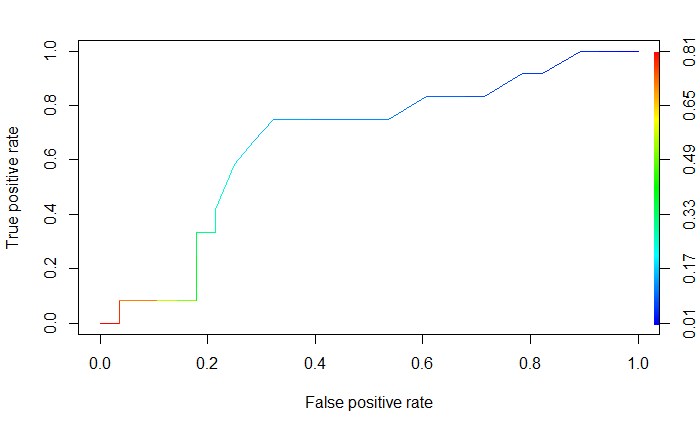

```r
rocpred <- prediction(banompreds, batest$nominee)
rocperf <- performance(rocpred, 'tpr', 'fpr')
plot(rocperf, colorize = TRUE, text.adj = c(-.2, 1.7))
```

```r
performance(rocpred, 'auc')
```

```
An object of class "performance"
Slot "x.name":
[1] "None"

Slot "y.name":
[1] "Area under the ROC curve"

Slot "alpha.name":
[1] "none"

Slot "x.values":
list()

Slot "y.values":
[[1]]
[1] 0.6666667


Slot "alpha.values":
list()
```

Yeah, ROC isn’t great - only .67. Maybe looking at the winners will be a better time? Lets try it out:

```r
logmodbawin <- glm(winner~.-nominee, data = batrain, family = binomial)
```

```
glm.fit: fitted probabilities numerically 0 or 1 occurred
```

```r
summary(logmodbawin)
```

```
Call:
glm(formula = winner ~ . - nominee, family = binomial, data = batrain)

Deviance Residuals:
     Min        1Q    Median        3Q       Max
-1.46921  -0.00001   0.00000   0.00000   2.05822

Coefficients:
                            Estimate Std. Error z value Pr(>|z|)
(Intercept)                  -36.693    181.236  -0.202    0.840
budget                         1.089      1.449   0.752    0.452
revenue                        5.527      5.209   1.061    0.289
runtime                        2.184      3.906   0.559    0.576
popularity                     1.516      1.503   1.009    0.313
average_rating                -3.851      9.292  -0.415    0.678
num_votes                      8.466     10.564   0.801    0.423
total_actor_credits            4.104      5.248   0.782    0.434
average_actor_popularity      -4.954      4.645  -1.066    0.286
actor_oscar_nominations        8.204     11.640   0.705    0.481
actor_oscar_wins             -10.238     13.002  -0.787    0.431
total_director_credits        -1.434      3.753  -0.382    0.702
average_director_popularity   -8.701      7.655  -1.137    0.256
director_oscar_nominations    25.729     21.519   1.196    0.232
director_oscar_wins          -15.739    752.094  -0.021    0.983

(Dispersion parameter for binomial family taken to be 1)

    Null deviance: 79.694  on 156  degrees of freedom
Residual deviance: 15.253  on 142  degrees of freedom
AIC: 45.253

Number of Fisher Scoring iterations: 18
```

So, I don’t think backwards elimination will help us here. Lets try a few iterations just to check:

```r
logmodbawin <- glm(winner~.-nominee-director_oscar_wins, data = batrain, family = binomial)
```

```
glm.fit: fitted probabilities numerically 0 or 1 occurred
```

```r
summary(logmodbawin)
```

```
Call:
glm(formula = winner ~ . - nominee - director_oscar_wins, family = binomial,
    data = batrain)

Deviance Residuals:
     Min        1Q    Median        3Q       Max
-1.31156  -0.00403  -0.00051  -0.00001   2.16819

Coefficients:
                            Estimate Std. Error z value Pr(>|z|)
(Intercept)                 -14.6855    10.6265  -1.382    0.167
budget                       -0.0578     0.7450  -0.078    0.938
revenue                       1.6556     1.3488   1.227    0.220
runtime                       3.1468     2.1745   1.447    0.148
popularity                    1.0492     0.9952   1.054    0.292
average_rating               -3.0440     3.6826  -0.827    0.408
num_votes                     5.3384     4.4755   1.193    0.233
total_actor_credits           2.1829     1.7692   1.234    0.217
average_actor_popularity     -0.3603     1.3456  -0.268    0.789
actor_oscar_nominations       4.7376     4.1677   1.137    0.256
actor_oscar_wins             -4.5541     4.0853  -1.115    0.265
total_director_credits       -1.7556     1.4673  -1.196    0.232
average_director_popularity  -3.7248     3.1506  -1.182    0.237
director_oscar_nominations    6.0668     4.4091   1.376    0.169

(Dispersion parameter for binomial family taken to be 1)

    Null deviance: 79.694  on 156  degrees of freedom
Residual deviance: 19.932  on 143  degrees of freedom
AIC: 47.932

Number of Fisher Scoring iterations: 12
```

```r
logmodbawin <- glm(winner~.-nominee-director_oscar_wins-budget, data = batrain, family = binomial)
```

```
glm.fit: fitted probabilities numerically 0 or 1 occurred
```

```r
summary(logmodbawin)
```

```
Call:
glm(formula = winner ~ . - nominee - director_oscar_wins - budget,
    family = binomial, data = batrain)

Deviance Residuals:
     Min        1Q    Median        3Q       Max
-1.30057  -0.00410  -0.00050  -0.00001   2.19725

Coefficients:
                            Estimate Std. Error z value Pr(>|z|)
(Intercept)                 -14.6852    10.5188  -1.396    0.163
revenue                       1.6378     1.3168   1.244    0.214
runtime                       3.0927     2.0593   1.502    0.133
popularity                    1.0609     1.0646   0.996    0.319
average_rating               -3.0540     3.6608  -0.834    0.404
num_votes                     5.3094     4.4356   1.197    0.231
total_actor_credits           2.1505     1.7025   1.263    0.207
average_actor_popularity     -0.3689     1.3437  -0.275    0.784
actor_oscar_nominations       4.7225     4.1315   1.143    0.253
actor_oscar_wins             -4.5167     4.0251  -1.122    0.262
total_director_credits       -1.7452     1.4539  -1.200    0.230
average_director_popularity  -3.6963     3.0712  -1.204    0.229
director_oscar_nominations    6.0304     4.3153   1.397    0.162

(Dispersion parameter for binomial family taken to be 1)

    Null deviance: 79.694  on 156  degrees of freedom
Residual deviance: 19.938  on 144  degrees of freedom
AIC: 45.938

Number of Fisher Scoring iterations: 12
```

```r
logmodbawin <- glm(winner~.-nominee-director_oscar_wins-budget-average_rating, data = batrain, family = binomial)
summary(logmodbawin)
```

```
Call:
glm(formula = winner ~ . - nominee - director_oscar_wins - budget -
    average_rating, family = binomial, data = batrain)

Deviance Residuals:
     Min        1Q    Median        3Q       Max
-1.45336  -0.03339  -0.00687  -0.00151   1.89204

Coefficients:
                            Estimate Std. Error z value Pr(>|z|)
(Intercept)                  -9.3221     4.0154  -2.322   0.0203 *
revenue                       1.1251     0.7179   1.567   0.1171
runtime                       2.4565     1.5868   1.548   0.1216
popularity                    0.7407     1.2410   0.597   0.5506
num_votes                     2.4251     1.2340   1.965   0.0494 *
total_actor_credits           1.2750     0.8139   1.567   0.1172
average_actor_popularity     -0.1714     1.2010  -0.143   0.8865
actor_oscar_nominations       2.1638     1.1549   1.874   0.0610 .
actor_oscar_wins             -2.2096     1.4645  -1.509   0.1313
total_director_credits       -0.7306     0.6633  -1.101   0.2707
average_director_popularity  -3.8957     2.8818  -1.352   0.1764
director_oscar_nominations    4.5909     2.7327   1.680   0.0930 .
---
Signif. codes:  0 ‘***’ 0.001 ‘**’ 0.01 ‘*’ 0.05 ‘.’ 0.1 ‘ ’ 1

(Dispersion parameter for binomial family taken to be 1)

    Null deviance: 79.694  on 156  degrees of freedom
Residual deviance: 21.186  on 145  degrees of freedom
AIC: 45.186

Number of Fisher Scoring iterations: 10
```

```r
logmodbawin <- glm(winner~.-nominee-director_oscar_wins-budget-average_rating-popularity, data = batrain, family = binomial)
summary(logmodbawin)
```

```
Call:
glm(formula = winner ~ . - nominee - director_oscar_wins - budget -
    average_rating - popularity, family = binomial, data = batrain)

Deviance Residuals:
     Min        1Q    Median        3Q       Max
-1.48666  -0.09780  -0.03026  -0.01151   2.26901

Coefficients:
                            Estimate Std. Error z value Pr(>|z|)
(Intercept)                 -5.51303    1.86200  -2.961  0.00307 **
revenue                      0.95193    0.55749   1.708  0.08773 .
runtime                      2.64181    1.28608   2.054  0.03996 *
num_votes                    1.63107    0.66276   2.461  0.01385 *
total_actor_credits          0.55333    0.57569   0.961  0.33647
average_actor_popularity     0.03901    0.69289   0.056  0.95510
actor_oscar_nominations      1.59081    0.87898   1.810  0.07032 .
actor_oscar_wins            -1.51959    1.05386  -1.442  0.14932
total_director_credits      -0.89558    0.68223  -1.313  0.18927
average_director_popularity -1.28962    1.39037  -0.928  0.35365
director_oscar_nominations   2.12709    1.30073   1.635  0.10198
---
Signif. codes:  0 ‘***’ 0.001 ‘**’ 0.01 ‘*’ 0.05 ‘.’ 0.1 ‘ ’ 1

(Dispersion parameter for binomial family taken to be 1)

    Null deviance: 79.694  on 156  degrees of freedom
Residual deviance: 29.311  on 146  degrees of freedom
AIC: 51.311

Number of Fisher Scoring iterations: 9
```

```r
logmodbawin <- glm(winner~.-nominee-director_oscar_wins-budget-average_rating-popularity-average_actor_popularity, data = batrain, family = binomial)
summary(logmodbawin)
```

```
Call:
glm(formula = winner ~ . - nominee - director_oscar_wins - budget -
    average_rating - popularity - average_actor_popularity, family = binomial,
    data = batrain)

Deviance Residuals:
     Min        1Q    Median        3Q       Max
-1.49004  -0.10122  -0.03090  -0.01157   2.26617

Coefficients:
                            Estimate Std. Error z value Pr(>|z|)
(Intercept)                  -5.4861     1.7890  -3.067  0.00217 **
revenue                       0.9549     0.5551   1.720  0.08541 .
runtime                       2.6392     1.2872   2.050  0.04034 *
num_votes                     1.6180     0.6164   2.625  0.00867 **
total_actor_credits           0.5452     0.5566   0.980  0.32729
actor_oscar_nominations       1.5895     0.8770   1.813  0.06991 .
actor_oscar_wins             -1.5090     1.0350  -1.458  0.14484
total_director_credits       -0.9002     0.6780  -1.328  0.18424
average_director_popularity  -1.2955     1.3833  -0.937  0.34900
director_oscar_nominations    2.1397     1.2797   1.672  0.09452 .
---
Signif. codes:  0 ‘***’ 0.001 ‘**’ 0.01 ‘*’ 0.05 ‘.’ 0.1 ‘ ’ 1

(Dispersion parameter for binomial family taken to be 1)

    Null deviance: 79.694  on 156  degrees of freedom
Residual deviance: 29.314  on 147  degrees of freedom
AIC: 49.314

Number of Fisher Scoring iterations: 8
```

```r
logmodbawin <- glm(winner~.-nominee-director_oscar_wins-budget-average_rating-popularity-average_actor_popularity-average_director_popularity, data = batrain, family = binomial)
summary(logmodbawin)
```

```
Call:
glm(formula = winner ~ . - nominee - director_oscar_wins - budget -
    average_rating - popularity - average_actor_popularity -
    average_director_popularity, family = binomial, data = batrain)

Deviance Residuals:
     Min        1Q    Median        3Q       Max
-1.31694  -0.10311  -0.03090  -0.01575   2.10436

Coefficients:
                           Estimate Std. Error z value Pr(>|z|)
(Intercept)                 -5.1002     1.6051  -3.178  0.00149 **
revenue                      0.8347     0.5192   1.607  0.10795
runtime                      2.5863     1.3038   1.984  0.04730 *
num_votes                    1.4915     0.5607   2.660  0.00782 **
total_actor_credits          0.5620     0.5659   0.993  0.32062
actor_oscar_nominations      1.4281     0.8479   1.684  0.09211 .
actor_oscar_wins            -1.2393     0.9552  -1.297  0.19447
total_director_credits      -1.1627     0.8137  -1.429  0.15301
director_oscar_nominations   1.2436     0.8480   1.467  0.14250
---
Signif. codes:  0 ‘***’ 0.001 ‘**’ 0.01 ‘*’ 0.05 ‘.’ 0.1 ‘ ’ 1

(Dispersion parameter for binomial family taken to be 1)

    Null deviance: 79.694  on 156  degrees of freedom
Residual deviance: 30.280  on 148  degrees of freedom
AIC: 48.28

Number of Fisher Scoring iterations: 8
```

```r
logmodbawin <- glm(winner~.-nominee-director_oscar_wins-budget-average_rating-popularity-average_actor_popularity-average_director_popularity-total_actor_credits, data = batrain, family = binomial)
summary(logmodbawin)
```

```
Call:
glm(formula = winner ~ . - nominee - director_oscar_wins - budget -
    average_rating - popularity - average_actor_popularity -
    average_director_popularity - total_actor_credits, family = binomial,
    data = batrain)

Deviance Residuals:
     Min        1Q    Median        3Q       Max
-1.24586  -0.10536  -0.03881  -0.01896   2.25438

Coefficients:
                           Estimate Std. Error z value Pr(>|z|)
(Intercept)                 -4.5664     1.3026  -3.506 0.000455 ***
revenue                      0.7155     0.4716   1.517 0.129261
runtime                      2.4236     1.2304   1.970 0.048865 *
num_votes                    1.4514     0.5507   2.636 0.008400 **
actor_oscar_nominations      1.3291     0.7800   1.704 0.088383 .
actor_oscar_wins            -0.9060     0.8629  -1.050 0.293715
total_director_credits      -1.2179     0.9731  -1.252 0.210742
director_oscar_nominations   1.2990     0.9541   1.362 0.173330
---
Signif. codes:  0 ‘***’ 0.001 ‘**’ 0.01 ‘*’ 0.05 ‘.’ 0.1 ‘ ’ 1

(Dispersion parameter for binomial family taken to be 1)

    Null deviance: 79.694  on 156  degrees of freedom
Residual deviance: 31.299  on 149  degrees of freedom
AIC: 47.299

Number of Fisher Scoring iterations: 8
```

```r
logmodbawin <- glm(winner~.-nominee-director_oscar_wins-budget-average_rating-popularity-average_actor_popularity-average_director_popularity-total_actor_credits-actor_oscar_wins, data = batrain, family = binomial)
summary(logmodbawin)
```

```
Call:
glm(formula = winner ~ . - nominee - director_oscar_wins - budget -
    average_rating - popularity - average_actor_popularity -
    average_director_popularity - total_actor_credits - actor_oscar_wins,
    family = binomial, data = batrain)

Deviance Residuals:
     Min        1Q    Median        3Q       Max
-1.15257  -0.11866  -0.04229  -0.02212   2.41998

Coefficients:
                           Estimate Std. Error z value Pr(>|z|)
(Intercept)                 -4.2015     1.1436  -3.674 0.000239 ***
revenue                      0.4633     0.3870   1.197 0.231267
runtime                      2.4166     1.1558   2.091 0.036543 *
num_votes                    1.5438     0.5296   2.915 0.003559 **
actor_oscar_nominations      0.6807     0.4618   1.474 0.140501
total_director_credits      -1.0261     0.8503  -1.207 0.227523
director_oscar_nominations   1.1470     0.8561   1.340 0.180325
---
Signif. codes:  0 ‘***’ 0.001 ‘**’ 0.01 ‘*’ 0.05 ‘.’ 0.1 ‘ ’ 1

(Dispersion parameter for binomial family taken to be 1)

    Null deviance: 79.694  on 156  degrees of freedom
Residual deviance: 32.592  on 150  degrees of freedom
AIC: 46.592

Number of Fisher Scoring iterations: 8
```

```r
logmodbawin <- glm(winner~.-nominee-director_oscar_wins-budget-average_rating-popularity-average_actor_popularity-average_director_popularity-total_actor_credits-actor_oscar_wins-revenue, data = batrain, family = binomial)
summary(logmodbawin)
```

```
Call:
glm(formula = winner ~ . - nominee - director_oscar_wins - budget -
    average_rating - popularity - average_actor_popularity -
    average_director_popularity - total_actor_credits - actor_oscar_wins -
    revenue, family = binomial, data = batrain)

Deviance Residuals:
     Min        1Q    Median        3Q       Max
-1.38849  -0.13074  -0.05700  -0.03011   2.22876

Coefficients:
                           Estimate Std. Error z value Pr(>|z|)
(Intercept)                 -3.6831     0.9370  -3.931 8.47e-05 ***
runtime                      2.3217     1.0680   2.174   0.0297 *
num_votes                    1.8316     0.4583   3.997 6.42e-05 ***
actor_oscar_nominations      0.6373     0.4059   1.570   0.1164
total_director_credits      -1.0528     0.8182  -1.287   0.1982
director_oscar_nominations   1.1213     0.8306   1.350   0.1770
---
Signif. codes:  0 ‘***’ 0.001 ‘**’ 0.01 ‘*’ 0.05 ‘.’ 0.1 ‘ ’ 1

(Dispersion parameter for binomial family taken to be 1)

    Null deviance: 79.694  on 156  degrees of freedom
Residual deviance: 34.091  on 151  degrees of freedom
AIC: 46.091

Number of Fisher Scoring iterations: 8
```

```r
logmodbawin <- glm(winner~.-nominee-director_oscar_wins-budget-average_rating-popularity-average_actor_popularity-average_director_popularity-total_actor_credits-actor_oscar_wins-revenue-total_director_credits, data = batrain, family = binomial)
summary(logmodbawin)
```

```
Call:
glm(formula = winner ~ . - nominee - director_oscar_wins - budget -
    average_rating - popularity - average_actor_popularity -
    average_director_popularity - total_actor_credits - actor_oscar_wins -
    revenue - total_director_credits, family = binomial, data = batrain)

Deviance Residuals:
     Min        1Q    Median        3Q       Max
-1.54934  -0.15175  -0.07749  -0.04695   2.30072

Coefficients:
                           Estimate Std. Error z value Pr(>|z|)
(Intercept)                 -3.7490     0.9185  -4.082 4.47e-05 ***
runtime                      1.6319     0.8820   1.850   0.0643 .
num_votes                    1.6270     0.3926   4.144 3.41e-05 ***
actor_oscar_nominations      0.4595     0.4084   1.125   0.2606
director_oscar_nominations   0.2807     0.4446   0.631   0.5278
---
Signif. codes:  0 ‘***’ 0.001 ‘**’ 0.01 ‘*’ 0.05 ‘.’ 0.1 ‘ ’ 1

(Dispersion parameter for binomial family taken to be 1)

    Null deviance: 79.694  on 156  degrees of freedom
Residual deviance: 37.772  on 152  degrees of freedom
AIC: 47.772

Number of Fisher Scoring iterations: 8
```

```r
logmodbawin <- glm(winner~.-nominee-director_oscar_wins-budget-average_rating-popularity-average_actor_popularity-average_director_popularity-total_actor_credits-actor_oscar_wins-revenue-total_director_credits-director_oscar_nominations, data = batrain, family = binomial)
summary(logmodbawin)
```

```
Call:
glm(formula = winner ~ . - nominee - director_oscar_wins - budget -
    average_rating - popularity - average_actor_popularity -
    average_director_popularity - total_actor_credits - actor_oscar_wins -
    revenue - total_director_credits - director_oscar_nominations,
    family = binomial, data = batrain)

Deviance Residuals:
     Min        1Q    Median        3Q       Max
-1.56344  -0.15993  -0.08202  -0.04988   2.40137

Coefficients:
                        Estimate Std. Error z value Pr(>|z|)
(Intercept)              -3.7153     0.8975  -4.140 3.48e-05 ***
runtime                   1.6361     0.8632   1.895    0.058 .
num_votes                 1.5884     0.3761   4.223 2.41e-05 ***
actor_oscar_nominations   0.4539     0.4214   1.077    0.281
---
Signif. codes:  0 ‘***’ 0.001 ‘**’ 0.01 ‘*’ 0.05 ‘.’ 0.1 ‘ ’ 1

(Dispersion parameter for binomial family taken to be 1)

    Null deviance: 79.694  on 156  degrees of freedom
Residual deviance: 38.059  on 153  degrees of freedom
AIC: 46.059

Number of Fisher Scoring iterations: 8
```

```r
logmodbawin <- glm(winner~.-nominee-director_oscar_wins-budget-average_rating-popularity-average_actor_popularity-average_director_popularity-total_actor_credits-actor_oscar_wins-revenue-total_director_credits-director_oscar_nominations-actor_oscar_nominations, data = batrain, family = binomial)
summary(logmodbawin)
```

```
Call:
glm(formula = winner ~ . - nominee - director_oscar_wins - budget -
    average_rating - popularity - average_actor_popularity -
    average_director_popularity - total_actor_credits - actor_oscar_wins -
    revenue - total_director_credits - director_oscar_nominations -
    actor_oscar_nominations, family = binomial, data = batrain)

Deviance Residuals:
     Min        1Q    Median        3Q       Max
-1.53103  -0.16649  -0.08501  -0.05761   2.56417

Coefficients:
            Estimate Std. Error z value Pr(>|z|)
(Intercept)  -3.5911     0.8256  -4.350 1.36e-05 ***
runtime       1.6475     0.8237   2.000   0.0455 *
num_votes     1.5592     0.3654   4.267 1.98e-05 ***
---
Signif. codes:  0 ‘***’ 0.001 ‘**’ 0.01 ‘*’ 0.05 ‘.’ 0.1 ‘ ’ 1

(Dispersion parameter for binomial family taken to be 1)

    Null deviance: 79.694  on 156  degrees of freedom
Residual deviance: 39.016  on 154  degrees of freedom
AIC: 45.016

Number of Fisher Scoring iterations: 7
```

Two variables left this time, runtime and num_votes! Not average rating though, unlike for the nominees. So longer, well-known nominees for the category will win? Lets see if this fits well.

```r
bawinpreds <- predict(logmodbawin, newdata = batest, type = "response")
```

Lets check the confusion matrix for this at, say a .5 cutoff.

```r
table(batest$winner, bawinpreds > 0.5)
```

```
    FALSE TRUE
  0    37    0
  1     0    3
```

Amazingly, this is perfect. There must be some mistake…

```r
table(batest$winner, bawinpreds > 0.09)
```

```
    FALSE TRUE
  0    36    1
  1     0    3
```

Loosening the cutoff actually leads to some error. Somehow, I stumbled on to a perfect model, which makes me immediately distrust it - perfect models shouldn’t exist…but lets go with it for now. Lets check the ROC, finally:

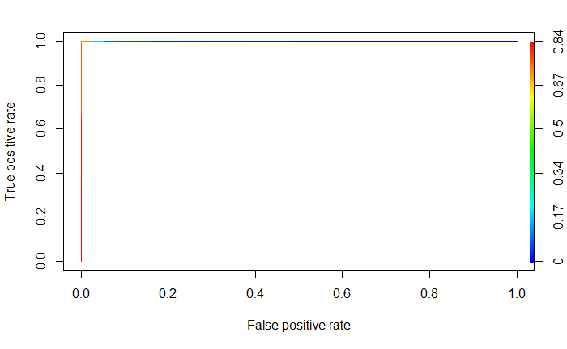

```r
rocpred <- prediction(bawinpreds, batest$winner)
rocperf <- performance(rocpred, 'tpr', 'fpr')
plot(rocperf, colorize = TRUE, text.adj = c(-.2, 1.7))
```

```r
performance(rocpred, 'auc')
```

```
An object of class "performance"
Slot "x.name":
[1] "None"

Slot "y.name":
[1] "Area under the ROC curve"

Slot "alpha.name":
[1] "none"

Slot "x.values":
list()

Slot "y.values":
[[1]]
[1] 1


Slot "alpha.values":
list()
```

There is something up with this, the AUC shouldn’t be 1. Unfortunately I’m not quite equipped to go digging for the issue, nor do I have the time.

So, lets see if this holds up. We’ll try to predict the nominees and winners of the Oscars for the most recent iteration.

First, we set the release dates as date type variables:

```r
bestpicture$release_date <- as.Date(bestpicture$release_date, "%Y-%m-%d")
```

Next, we subset:

```r
bp2017 <- bestpicture[bestpicture$release_date >= as.Date("2017-01-01"),]
```

And now, the nominees are:

```r
nombp2017 <- predict(logmodbpnom, newdata = bp2017, type = "response")
table(bp2017$nominee, nombp2017>.1)
```

```
    FALSE TRUE
  0    94   12
  1     1    6
```

With that cutoff, we get that our nominees are:

```r
bp2017[nombp2017>.1,"title"]
```

```
 [1] "Logan"                "The Greatest Showman" "Baby Driver"          "It"                   "Paddington 2"         "Dunkirk"              "A Dog's Purpose"      "The Book of Henry"
 [9] "I, Tonya"             "Lady Bird"            "Wind River"           "Call Me by Your Name" "Phantom Thread"       "Gifted"               "I Am Not Your Negro"  "The Big Sick"
[17] "Get Out"              "The Post"
```

And our predicted winner(s):

```r
winbp2017 <- predict(logmodbpwin, newdata = bp2017, type="response")
table(bp2017$winner, winbp2017>.04)
```

```
    FALSE TRUE
  0   109    3
  1     0    1
```

Close! our reported winners are:

```r
bp2017[winbp2017>.04,"title"]
```

```
[1] "Call Me by Your Name" "The Shape of Water"   "I Am Not Your Negro"  "Get Out"
```

The winner was, in fact, *The Shape Of Water*.

Now time for the best animated feature!

```r
bestanim$release_date <- as.Date(bestanim$release_date, "%Y-%m-%d")
ba2017 <- bestanim[bestanim$release_date >= as.Date("2017-01-01"),]
```

And now, your nominees for best animated feature:

```r
nomba2017 <- predict(logmodbanom, newdata = ba2017, type = "response")
table(ba2017$nominee, nomba2017>.09)
```

```
    FALSE TRUE
  0     3    4
  1     0    3
```

The titles are:

```r
ba2017[nomba2017>.09, "title"]
```

```
[1] "Cars 3"                "The Boss Baby"         "The Lego Batman Movie" "Despicable Me 3"       "Loving Vincent"        "Coco"                  "Ferdinand"
```

As for the winner:

```r
winba2017 <- predict(logmodbawin, newdata = ba2017, type = "response")
table(ba2017$winner, winba2017>.09)
```

```
    FALSE TRUE
  0     9    0
  1     0    1
```

And the title is:

```r
ba2017[winba2017>.09, "title"]
```

```
[1] "Coco"
```

*Coco* Was indeed the winner! So all in all, not bad. We got a few more winners/nominees than we should, but we did cover the true winner. So, at the very least, you could probably use these models to win an Oscars bet, but maybe not use it in the industry as a good classifier just yet.